# Polymarket Bias & Mispricing Analysis

Closed Markets 2025 — Calibration, Exploitable Edges & Bot Strategy (v4)

Laurence

2026-02-19

# 1 · Setup & Data Loading

```r
# ── Paths (change these once) ─────────────────────────────────────────────
DATA_DIR   <- "../data"
MARKET_FILE <- file.path(DATA_DIR, "markets_2025_closed.parquet")
PRICE_FILE  <- file.path(DATA_DIR, "markets_2025_closed_price_history.parquet")

# ── Trading cost assumptions ──────────────────────────────────────────────
SPREAD_COST   <- 0.02   # typical ~2% bid-ask spread on liquid markets
WINNER_FEE    <- 0.02   # ~2% fee on winning payouts
MIN_EDGE_NET  <- 0.01   # minimum net edge (after costs) to consider tradeable
MIN_N_EXPLOIT <- 15     # minimum markets in a segment to consider exploitable
MIN_VOLUME    <- 10000  # minimum volume ($) for liquidity-filtered analysis
```

```r
library(arrow)
library(dplyr)
library(tidyr)
library(stringr)
library(ggplot2)
library(jsonlite)
library(lubridate)
library(scales)
library(purrr)
library(boot)
library(data.table)

theme_poly <- theme_minimal(base_size = 13) +
  theme(
    plot.title       = element_text(face = "bold", size = 15),
    plot.subtitle    = element_text(color = "grey40"),
    panel.grid.minor = element_blank(),
    legend.position  = "bottom"
  )
theme_set(theme_poly)

COL_POS  <- "#2ecc71"
COL_NEG  <- "#e74c3c"
COL_NEUT <- "grey70"
COL_BLUE <- "#3498db"
COL_ORNG <- "#e67e22"
COL_PURP <- "#9b59b6"
```

```r
df <- read_parquet(MARKET_FILE)
cat(nrow(df), "market rows loaded\n")
```

```
## 111178 market rows loaded
```

```r
cat(ncol(df), "columns\n")
```

```
## 87 columns
```

## 1.1 Parse Resolutions & Token Mapping

```r
safe_parse_json <- function(x) tryCatch(fromJSON(x), error = function(e) NA)

df_parsed <- df %>%
  filter(closed == TRUE) %>%
  rowwise() %>%
  mutate(
    outcomes_list = list(tryCatch(fromJSON(outcomes),       error = function(e) NA_character_)),
    prices_list   = list(tryCatch(fromJSON(outcome_prices), error = function(e) NA_character_)),
    tokens_list   = list(tryCatch(fromJSON(token_ids),      error = function(e) NA_character_))
  ) %>%
  ungroup()

df_binary <- df_parsed %>%
  mutate(
    n_outcomes = lengths(outcomes_list),
    is_binary  = n_outcomes == 2,
    yes_idx    = map_int(outcomes_list, ~ {
      idx <- which(tolower(.x) == "yes")
      if (length(idx) == 1) idx else NA_integer_
    })
  ) %>%
  filter(is_binary, !is.na(yes_idx)) %>%
  mutate(
    yes_token_id   = map2_chr(tokens_list, yes_idx, ~ .x[.y]),
    yes_resolution = map2_dbl(prices_list, yes_idx, ~ as.numeric(.x[.y])),
    no_idx         = ifelse(yes_idx == 1, 2, 1),
    no_token_id    = map2_chr(tokens_list, no_idx, ~ .x[.y])
  ) %>%
  filter(!is.na(yes_resolution), yes_resolution %in% c(0, 1))

cat(nrow(df_binary), "binary Yes/No markets with clean resolution\n")
```

```
## 49753 binary Yes/No markets with clean resolution
```

```r
cat("Resolution rate (Yes = 1):", round(mean(df_binary$yes_resolution), 3), "\n")
```

```
## Resolution rate (Yes = 1): 0.267
```

## 1.2 Derive Categories from Tags

```r
category_rules <- tibble::tribble(
  ~category,       ~pattern,
  "Sports",        "nba|nfl|mlb|nhl|soccer|football|tennis|boxing|mma|ufc|cricket|esports|dota|league of legends|sports|epl|la liga|bundesliga|serie a|ligue 1|f1|formula|nascar|golf|olympics|pga",
  "Crypto",        "crypto|bitcoin|btc|ethereum|eth|solana|sol|defi|blockchain|token|nft|altcoin|memecoin|binance|coinbase",
  "Politics",      "politic|election|trump|biden|democrat|republican|congress|senate|governor|president|vote|gop|dnc|rnc|parliament|minister|legislation|bill|law|executive order",
  "Economics",     "econom|fed |federal reserve|interest rate|inflation|gdp|employment|jobs|recession|tariff|trade|stock market|s&p|nasdaq|dow jones|treasury|debt|cpi",
  "Science/Tech",  "science|tech|ai |artificial intelligence|openai|google|apple|microsoft|space|spacex|nasa|climate|weather|earthquake|hurricane|temperature",
  "Entertainment", "movie|film|oscar|grammy|emmy|music|album|box office|streaming|netflix|youtube|tiktok|celebrity|award|tv show|series",
  "World Events",  "war|conflict|ukraine|russia|china|israel|gaza|nato|united nations|refugee|disaster|pandemic",
  "Other",         ".*"
)

assign_category <- function(tags) {
  if (is.na(tags) || tags == "") return("Other")
  combined <- tolower(tags)
  for (i in seq_len(nrow(category_rules))) {
    if (str_detect(combined, category_rules$pattern[i])) return(category_rules$category[i])
  }
  "Other"
}

df_binary <- df_binary %>%
  mutate(
    category    = map_chr(event_tags, assign_category),
    is_election = category == "Politics" &
      str_detect(tolower(event_tags),
        "trump|biden|harris|presidential|house|senate|congress|election 2024|midterm|ballot")
  )

cat("\n── Category distribution ──\n")
```

```
##
## ── Category distribution ──
```

```r
df_binary %>% count(category, sort = TRUE) %>% print()
```

```
## # A tibble: 8 × 2
##   category          n
##   <chr>         <int>
## 1 Sports        14881
## 2 Crypto        14161
## 3 Politics       9844
## 4 Science/Tech   5570
## 5 Other          2410
## 6 Entertainment  2091
## 7 Economics       777
## 8 World Events     19
```

```r
cat("\nPolitics: election-tagged =",
    sum(df_binary$is_election, na.rm = TRUE), "/",
    sum(df_binary$category == "Politics"), "\n")
```

```
##
## Politics: election-tagged = 4628 / 9844
```

# 2 · Calibration Analysis (Snapshot Prices)

The core question: **when the market prices a Yes token at probability $p$, does the event actually happen $p$% of the time?**

```r
token_lookup <- df_binary %>%
  select(yes_token_id, yes_resolution, id, event_title, category,
         is_election, closed_time, volume_num) %>%
  rename(token_id = yes_token_id) %>%
  mutate(closed_dt = ymd_hms(closed_time, quiet = TRUE)) %>%
  filter(!is.na(closed_dt))

yes_tokens <- unique(token_lookup$token_id)
cat(length(yes_tokens), "unique Yes tokens to look up\n")
```

```
## 49753 unique Yes tokens to look up
```

```r
dfp_arrow <- open_dataset(PRICE_FILE)

snapshots       <- c(1, 6, 24, 72, 168, 720)
snapshot_labels <- c("1h", "6h", "1d", "3d", "1w", "1mo")

BATCH_SIZE    <- 500
token_batches <- split(yes_tokens, ceiling(seq_along(yes_tokens) / BATCH_SIZE))
cat(length(token_batches), "batches of up to", BATCH_SIZE, "tokens\n")
```

```
## 100 batches of up to 500 tokens
```

```r
get_snapshot_price <- function(hbc, price, target_hours) {
  diffs <- abs(hbc - target_hours)
  valid <- diffs < (target_hours * 0.5 + 1)
  if (!any(valid)) return(NA_real_)
  price[valid][which.min(diffs[valid])]
}

snapshot_list  <- vector("list", length(token_batches))
mkt_stats_list <- vector("list", length(token_batches))

for (i in seq_along(token_batches)) {
  batch_tokens <- token_batches[[i]]

  batch_prices <- dfp_arrow %>%
    filter(token_id %in% batch_tokens) %>%
    select(token_id, timestamp, price) %>%
    collect()

  if (nrow(batch_prices) == 0) next

  batch_prices <- batch_prices %>%
    inner_join(
      token_lookup %>% select(token_id, yes_resolution, id, category,
                               is_election, volume_num, closed_dt),
      by = "token_id"
    ) %>%
    mutate(hours_before_close = as.numeric(
      difftime(closed_dt, timestamp, units = "hours")
    )) %>%
    filter(hours_before_close >= 0)

  if (nrow(batch_prices) == 0) next

  # ── Snapshot prices ───────────────────────────────────────────────
  batch_snap <- batch_prices %>%
    group_by(token_id, id, yes_resolution, category, is_election, volume_num) %>%
    summarise(
      across_snapshots = list(tibble(
        snapshot_hours = snapshots,
        snapshot_label = snapshot_labels,
        snap_price     = map_dbl(snapshots, ~ get_snapshot_price(hours_before_close, price, .x))
      )),
      .groups = "drop"
    ) %>%
    unnest(across_snapshots) %>%
    filter(!is.na(snap_price))

  snapshot_list[[i]] <- batch_snap

  # ── Per-market summary stats ────────────────────────────────────────
  mkt_summary <- batch_prices %>%
    arrange(token_id, desc(hours_before_close)) %>%
    group_by(token_id, id, yes_resolution, category, is_election, volume_num, closed_dt) %>%
    summarise(
      initial_price      = first(price),
      final_price        = last(price),
      min_price          = min(price),
      max_price          = max(price),
      price_range        = max(price) - min(price),
      n_obs              = n(),
      market_duration_h  = max(hours_before_close),
      price_sd           = if_else(n() > 2, sd(price), NA_real_),
      .groups            = "drop"
    )

  mkt_stats_list[[i]] <- mkt_summary

  if (i %% 5 == 0 || i == length(token_batches)) {
    cat(sprintf("  Batch %d/%d done (%d snapshot rows so far)\n",
                i, length(token_batches),
                sum(map_int(snapshot_list, ~ if (is.null(.x)) 0L else nrow(.x)))))
  }

  rm(batch_prices, batch_snap, mkt_summary); gc(verbose = FALSE)
}
```

```
##   Batch 5/100 done (11595 snapshot rows so far)
##   Batch 10/100 done (23809 snapshot rows so far)
##   Batch 15/100 done (36470 snapshot rows so far)
##   Batch 20/100 done (48962 snapshot rows so far)
##   Batch 25/100 done (61591 snapshot rows so far)
##   Batch 30/100 done (74504 snapshot rows so far)
##   Batch 35/100 done (87249 snapshot rows so far)
##   Batch 40/100 done (100113 snapshot rows so far)
##   Batch 45/100 done (112551 snapshot rows so far)
##   Batch 50/100 done (123420 snapshot rows so far)
##   Batch 55/100 done (133622 snapshot rows so far)
##   Batch 60/100 done (145422 snapshot rows so far)
##   Batch 65/100 done (157735 snapshot rows so far)
##   Batch 70/100 done (169985 snapshot rows so far)
##   Batch 75/100 done (181988 snapshot rows so far)
##   Batch 80/100 done (194828 snapshot rows so far)
##   Batch 85/100 done (207703 snapshot rows so far)
##   Batch 90/100 done (220378 snapshot rows so far)
##   Batch 95/100 done (232904 snapshot rows so far)
##   Batch 100/100 done (245827 snapshot rows so far)
```

```r
snapshot_data <- bind_rows(snapshot_list)
market_stats  <- bind_rows(mkt_stats_list)
rm(snapshot_list, mkt_stats_list, dfp_arrow); gc()
```

```
##            used  (Mb) gc trigger  (Mb)  max used  (Mb)
## Ncells  3526771 188.4    5795942 309.6   5795942 309.6
## Vcells 43051343 328.5  121389701 926.2 121388229 926.2
```

```r
cat("\n", nrow(snapshot_data), "total market × snapshot observations\n")
```

```
##
##  245827 total market × snapshot observations
```

```r
cat(nrow(market_stats), "markets with full price history stats\n")
```

```
## 49753 markets with full price history stats
```

## 2.1 Overall Calibration Curve

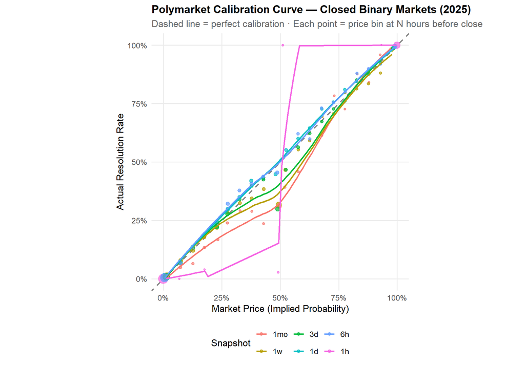

```r
calibration <- snapshot_data %>%
  mutate(
    price_bin    = cut(snap_price, breaks = seq(0, 1, by = 0.05),
                       include.lowest = TRUE, labels = FALSE),
    bin_midpoint = (price_bin - 1) * 0.05 + 0.025
  ) %>%
  filter(!is.na(price_bin)) %>%
  group_by(snapshot_label, bin_midpoint) %>%
  summarise(n = n(), actual_pct = mean(yes_resolution), avg_price = mean(snap_price), .groups = "drop") %>%
  mutate(snapshot_label = factor(snapshot_label, levels = c("1mo","1w","3d","1d","6h","1h")))

ggplot(calibration %>% filter(n >= 20), aes(x = avg_price, y = actual_pct)) +
  geom_abline(slope = 1, intercept = 0, linetype = "dashed", color = "grey50", linewidth = 0.8) +
  geom_point(aes(size = n, color = snapshot_label), alpha = 0.7) +
  geom_smooth(aes(color = snapshot_label, weight = n), method = "loess", se = FALSE, linewidth = 1) +
  scale_x_continuous(labels = percent, limits = c(0,1)) +
  scale_y_continuous(labels = percent, limits = c(0,1)) +
  scale_size_continuous(range = c(1,6), guide = "none") +
  coord_equal() +
  labs(
    title    = "Polymarket Calibration Curve — Closed Binary Markets (2025)",
    subtitle = "Dashed line = perfect calibration · Each point = price bin at N hours before close",
    x = "Market Price (Implied Probability)", y = "Actual Resolution Rate", color = "Snapshot"
  )
```

## 2.2 Calibration Error by Snapshot Horizon

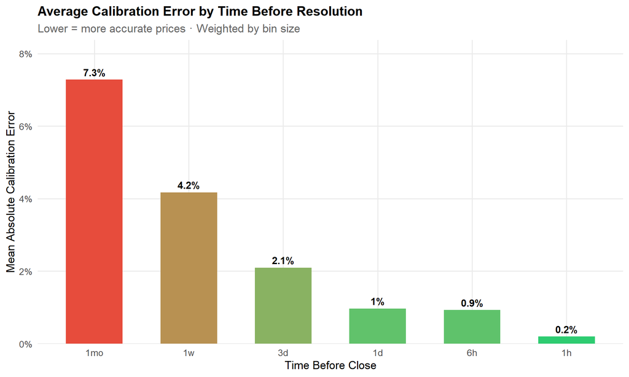

```r
cal_error <- snapshot_data %>%
  mutate(price_bin = round(snap_price * 20) / 20) %>%
  group_by(snapshot_label, price_bin) %>%
  summarise(n = n(), actual = mean(yes_resolution), predicted = mean(snap_price), .groups = "drop") %>%
  filter(n >= 10) %>%
  group_by(snapshot_label) %>%
  summarise(
    weighted_cal_error = weighted.mean(abs(actual - predicted), w = n),
    n_bins             = n(),
    total_obs          = sum(n),
    .groups            = "drop"
  ) %>%
  mutate(snapshot_label = factor(snapshot_label, levels = c("1mo","1w","3d","1d","6h","1h")))

ggplot(cal_error, aes(x = snapshot_label, y = weighted_cal_error)) +
  geom_col(aes(fill = weighted_cal_error), width = 0.6, show.legend = FALSE) +
  geom_text(aes(label = paste0(round(weighted_cal_error*100,1),"%")),
            vjust = -0.5, fontface = "bold", size = 4) +
  scale_fill_gradient(low = COL_POS, high = COL_NEG) +
  scale_y_continuous(labels = percent, expand = expansion(mult = c(0, 0.15))) +
  labs(
    title    = "Average Calibration Error by Time Before Resolution",
    subtitle = "Lower = more accurate prices · Weighted by bin size",
    x = "Time Before Close", y = "Mean Absolute Calibration Error"
  )
```

## 2.3 Favorite–Longshot Bias

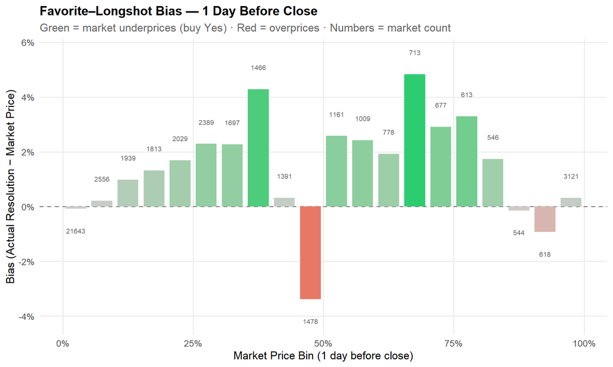

```r
fl_data <- snapshot_data %>%
  filter(snapshot_label == "1d") %>%
  mutate(
    price_bin    = cut(snap_price, breaks = seq(0,1,by=0.05),
                       include.lowest = TRUE, labels = FALSE),
    bin_midpoint = (price_bin - 1) * 0.05 + 0.025
  ) %>%
  filter(!is.na(price_bin)) %>%
  group_by(bin_midpoint) %>%
  summarise(
    n = n(), actual = mean(yes_resolution), predicted = mean(snap_price),
    bias = actual - predicted, .groups = "drop"
  )

ggplot(fl_data %>% filter(n >= 15), aes(x = bin_midpoint, y = bias)) +
  geom_hline(yintercept = 0, linetype = "dashed", color = "grey50") +
  geom_col(aes(fill = bias), width = 0.04, show.legend = FALSE) +
  geom_text(aes(label = n, y = ifelse(bias >= 0, bias + 0.008, bias - 0.008)),
            size = 2.8, color = "grey40") +
  scale_fill_gradient2(low = COL_NEG, mid = "grey80", high = COL_POS, midpoint = 0) +
  scale_x_continuous(labels = percent) +
  scale_y_continuous(labels = percent) +
  labs(
    title    = "Favorite–Longshot Bias — 1 Day Before Close",
    subtitle = "Green = market underprices (buy Yes) · Red = overprices · Numbers = market count",
    x = "Market Price Bin (1 day before close)", y = "Bias (Actual Resolution − Market Price)"
  )
```

## 2.4 Initial Price Calibration (Conditional)

**Important**: The naive aggregate “initial bias” (initial price minus resolution averaged across all markets) is misleading because it conflates the base rate of Yes resolutions (≈27%) with a default opening price near 50%. The correct test is *conditional*: for markets **opening in a given price bin**, does the resolution rate match that bin? This isolates real initial mispricing from compositional effects.

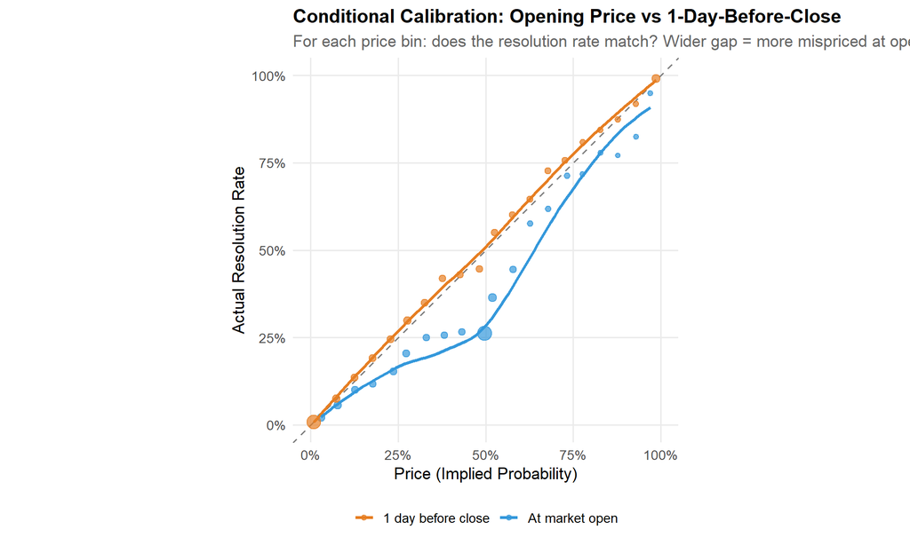

```r
init_cal <- market_stats %>%
  filter(!is.na(initial_price), !is.na(yes_resolution), market_duration_h >= 24) %>%
  mutate(
    init_bin     = cut(initial_price, breaks = seq(0, 1, by = 0.05),
                       include.lowest = TRUE, labels = FALSE),
    bin_midpoint = (init_bin - 1) * 0.05 + 0.025
  ) %>%
  filter(!is.na(init_bin)) %>%
  group_by(bin_midpoint) %>%
  summarise(
    n           = n(),
    actual_rate = mean(yes_resolution),
    avg_init    = mean(initial_price),
    cond_bias   = mean(yes_resolution) - mean(initial_price),
    .groups     = "drop"
  )

# Also compute for 1d snapshot for comparison
close_cal <- snapshot_data %>%
  filter(snapshot_label == "1d") %>%
  mutate(
    price_bin    = cut(snap_price, breaks = seq(0, 1, by = 0.05),
                       include.lowest = TRUE, labels = FALSE),
    bin_midpoint = (price_bin - 1) * 0.05 + 0.025
  ) %>%
  filter(!is.na(price_bin)) %>%
  group_by(bin_midpoint) %>%
  summarise(
    n           = n(),
    actual_rate = mean(yes_resolution),
    avg_price   = mean(snap_price),
    cond_bias   = mean(yes_resolution) - mean(snap_price),
    .groups     = "drop"
  )

# Combine for overlay plot
init_vs_close_cal <- bind_rows(
  init_cal %>% mutate(stage = "At market open") %>% rename(price = avg_init),
  close_cal %>% mutate(stage = "1 day before close") %>% rename(price = avg_price)
)

ggplot(init_vs_close_cal %>% filter(n >= 15),
       aes(x = price, y = actual_rate, color = stage)) +
  geom_abline(slope = 1, intercept = 0, linetype = "dashed", color = "grey50") +
  geom_point(aes(size = n), alpha = 0.7) +
  geom_smooth(aes(weight = n), method = "loess", se = FALSE, linewidth = 1.2) +
  scale_x_continuous(labels = percent, limits = c(0, 1)) +
  scale_y_continuous(labels = percent, limits = c(0, 1)) +
  scale_size_continuous(range = c(1.5, 5), guide = "none") +
  scale_color_manual(values = c("At market open" = COL_BLUE, "1 day before close" = COL_ORNG)) +
  coord_equal() +
  labs(
    title    = "Conditional Calibration: Opening Price vs 1-Day-Before-Close",
    subtitle = "For each price bin: does the resolution rate match? Wider gap = more mispriced at open",
    x = "Price (Implied Probability)", y = "Actual Resolution Rate", color = NULL
  )
```

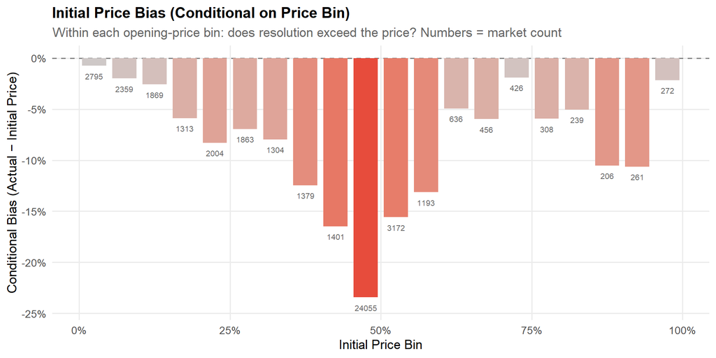

```r
ggplot(init_cal %>% filter(n >= 15), aes(x = bin_midpoint, y = cond_bias)) +
  geom_hline(yintercept = 0, linetype = "dashed", color = "grey50") +
  geom_col(aes(fill = cond_bias), width = 0.04, show.legend = FALSE) +
  geom_text(aes(label = n, y = ifelse(cond_bias >= 0, cond_bias + 0.01, cond_bias - 0.01)),
            size = 2.8, color = "grey40") +
  scale_fill_gradient2(low = COL_NEG, mid = "grey80", high = COL_POS, midpoint = 0) +
  scale_x_continuous(labels = percent) +
  scale_y_continuous(labels = percent) +
  labs(
    title    = "Initial Price Bias (Conditional on Price Bin)",
    subtitle = "Within each opening-price bin: does resolution exceed the price? Numbers = market count",
    x = "Initial Price Bin", y = "Conditional Bias (Actual − Initial Price)"
  )
```

```r
cat("── Initial price calibration (conditional, within-bin) ──\n")
```

```
## ── Initial price calibration (conditional, within-bin) ──
```

```r
cat(sprintf("  Weighted mean absolute bias (initial):    %.2f%%\n",
    weighted.mean(abs(init_cal$cond_bias[init_cal$n >= 15]),
                  w = init_cal$n[init_cal$n >= 15]) * 100))
```

```
##   Weighted mean absolute bias (initial):    15.65%
```

```r
cat(sprintf("  Weighted mean absolute bias (1d close):   %.2f%%\n",
    weighted.mean(abs(close_cal$cond_bias[close_cal$n >= 15]),
                  w = close_cal$n[close_cal$n >= 15]) * 100))
```

```
##   Weighted mean absolute bias (1d close):   1.00%
```

```r
cat("  (If initial >> close, new markets are genuinely mispriced and correct over time)\n")
```

```
##   (If initial >> close, new markets are genuinely mispriced and correct over time)
```

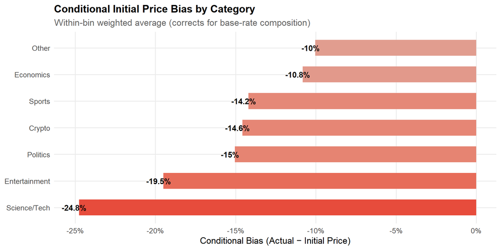

```r
# Conditional initial bias by category (within-bin average, not raw aggregate)
init_cat_cond <- market_stats %>%
  filter(!is.na(initial_price), market_duration_h >= 24) %>%
  mutate(
    init_bin = cut(initial_price, breaks = seq(0, 1, by = 0.10),
                   include.lowest = TRUE, labels = FALSE),
    bin_mid  = (init_bin - 1) * 0.10 + 0.05
  ) %>%
  filter(!is.na(init_bin)) %>%
  group_by(category, bin_mid) %>%
  summarise(
    n    = n(),
    bias = mean(yes_resolution) - mean(initial_price),
    .groups = "drop"
  ) %>%
  filter(n >= 10) %>%
  group_by(category) %>%
  summarise(
    n_bins        = n(),
    n_total       = sum(n),
    cond_init_bias = weighted.mean(bias, w = n),
    .groups       = "drop"
  ) %>%
  filter(n_total >= 50)

ggplot(init_cat_cond, aes(x = reorder(category, cond_init_bias), y = cond_init_bias)) +
  geom_col(aes(fill = cond_init_bias), width = 0.6, show.legend = FALSE) +
  geom_text(aes(label = paste0(ifelse(cond_init_bias > 0, "+", ""),
                                round(cond_init_bias * 100, 1), "%"),
                y = cond_init_bias + sign(cond_init_bias) * 0.003),
            fontface = "bold", size = 4) +
  scale_fill_gradient2(low = COL_NEG, mid = "grey80", high = COL_POS, midpoint = 0) +
  scale_y_continuous(labels = percent) +
  coord_flip() +
  labs(
    title    = "Conditional Initial Price Bias by Category",
    subtitle = "Within-bin weighted average (corrects for base-rate composition)",
    x = NULL, y = "Conditional Bias (Actual − Initial Price)"
  )
```

# 3 · Category-Level Mispricings

## 3.1 Category Calibration Curves

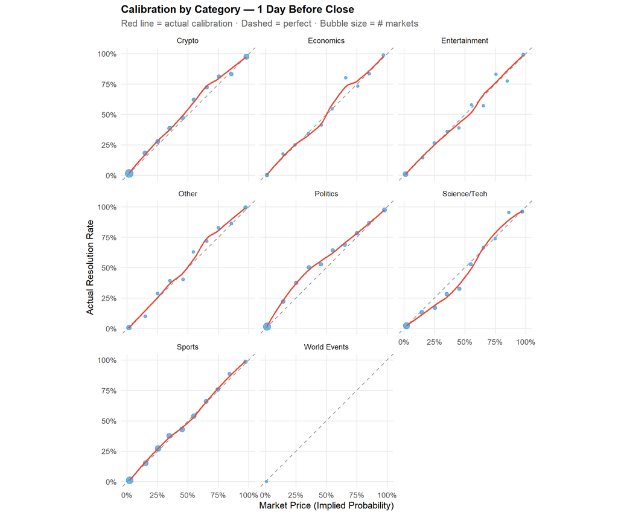

```r
cat_cal <- snapshot_data %>%
  filter(snapshot_label == "1d") %>%
  mutate(
    price_bin    = cut(snap_price, breaks = seq(0,1,by=0.10),
                       include.lowest = TRUE, labels = FALSE),
    bin_midpoint = (price_bin - 1) * 0.10 + 0.05
  ) %>%
  filter(!is.na(price_bin)) %>%
  group_by(category, bin_midpoint) %>%
  summarise(n = n(), actual = mean(yes_resolution), predicted = mean(snap_price), .groups = "drop")

ggplot(cat_cal %>% filter(n >= 10), aes(x = predicted, y = actual)) +
  geom_abline(slope = 1, intercept = 0, linetype = "dashed", color = "grey60") +
  geom_point(aes(size = n), color = COL_BLUE, alpha = 0.7) +
  geom_smooth(aes(weight = n), method = "loess", se = FALSE, color = COL_NEG, linewidth = 1) +
  facet_wrap(~ category, ncol = 3) +
  scale_x_continuous(labels = percent, limits = c(0,1)) +
  scale_y_continuous(labels = percent, limits = c(0,1)) +
  scale_size_continuous(range = c(1.5,5), guide = "none") +
  coord_equal() +
  labs(
    title    = "Calibration by Category — 1 Day Before Close",
    subtitle = "Red line = actual calibration · Dashed = perfect · Bubble size = # markets",
    x = "Market Price (Implied Probability)", y = "Actual Resolution Rate"
  )
```

## 3.2 Category × Price Zone Bias Heatmap

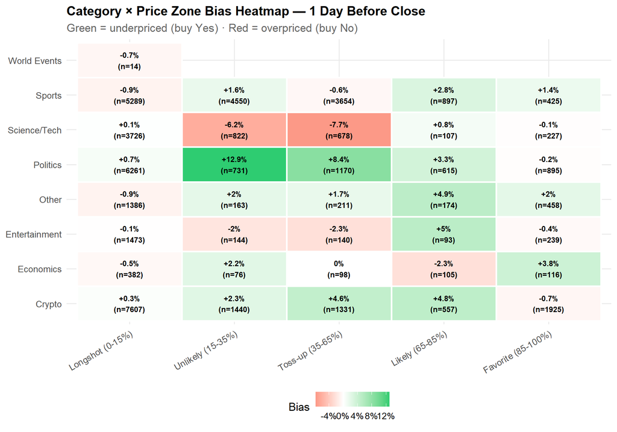

```r
# Helper to create price zone factor (used throughout)
make_price_zone <- function(price) {
  factor(
    case_when(
      price <= 0.15 ~ "Longshot (0-15%)",
      price <= 0.35 ~ "Unlikely (15-35%)",
      price <= 0.65 ~ "Toss-up (35-65%)",
      price <= 0.85 ~ "Likely (65-85%)",
      TRUE          ~ "Favorite (85-100%)"
    ),
    levels = c("Longshot (0-15%)", "Unlikely (15-35%)", "Toss-up (35-65%)",
               "Likely (65-85%)", "Favorite (85-100%)")
  )
}

cat_bias <- snapshot_data %>%
  filter(snapshot_label == "1d") %>%
  mutate(price_zone = make_price_zone(snap_price)) %>%
  group_by(category, price_zone) %>%
  summarise(n = n(), bias = mean(yes_resolution) - mean(snap_price), .groups = "drop") %>%
  filter(n >= 10)

ggplot(cat_bias, aes(x = price_zone, y = category, fill = bias)) +
  geom_tile(color = "white", linewidth = 1) +
  geom_text(aes(label = paste0(ifelse(bias > 0,"+",""), round(bias*100,1),"%\n(n=",n,")")),
            size = 3.2, fontface = "bold") +
  scale_fill_gradient2(low = COL_NEG, mid = "white", high = COL_POS, midpoint = 0,
                       labels = percent, name = "Bias") +
  labs(
    title    = "Category × Price Zone Bias Heatmap — 1 Day Before Close",
    subtitle = "Green = underpriced (buy Yes) · Red = overpriced (buy No)",
    x = NULL, y = NULL
  ) +
  theme(axis.text.x = element_text(angle = 30, hjust = 1))
```

## 3.3 Aggregate Category Bias & Brier Score

```r
cat_stats <- snapshot_data %>%
  filter(snapshot_label == "1d") %>%
  group_by(category) %>%
  summarise(
    n_markets       = n(),
    avg_price       = mean(snap_price),
    resolution_rate = mean(yes_resolution),
    bias            = mean(yes_resolution) - mean(snap_price),
    brier_score     = mean((snap_price - yes_resolution)^2),
    abs_bias        = mean(abs(yes_resolution - snap_price)),
    .groups         = "drop"
  ) %>%
  arrange(desc(abs(bias)))

cat_stats %>%
  mutate(across(where(is.numeric), ~ round(.x, 4))) %>%
  knitr::kable(caption = "Category-Level Bias & Accuracy (1 day before close)")
```

Category-Level Bias & Accuracy (1 day before close)

| category | n_markets | avg_price | resolution_rate | bias | brier_score | abs_bias |
| --- | --- | --- | --- | --- | --- | --- |
| World Events | 18 | 0.1137 | 0.2222 | 0.1085 | 0.0650 | 0.1193 |
| Politics | 9672 | 0.2265 | 0.2529 | 0.0264 | 0.0755 | 0.1431 |
| Science/Tech | 5560 | 0.1656 | 0.1480 | -0.0176 | 0.0743 | 0.1533 |
| Crypto | 12860 | 0.2694 | 0.2796 | 0.0102 | 0.0732 | 0.1438 |
| Other | 2392 | 0.3098 | 0.3148 | 0.0050 | 0.0554 | 0.1200 |
| Sports | 14815 | 0.2823 | 0.2846 | 0.0022 | 0.1407 | 0.2826 |
| Economics | 777 | 0.3403 | 0.3423 | 0.0020 | 0.0846 | 0.1735 |
| Entertainment | 2089 | 0.2061 | 0.2044 | -0.0017 | 0.0473 | 0.0972 |

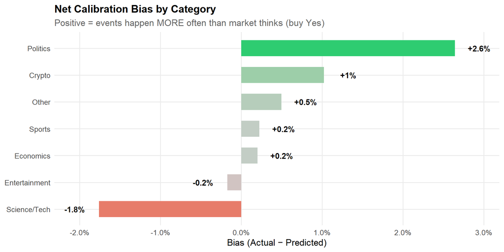

```r
ggplot(cat_stats %>% filter(n_markets >= 20),
       aes(x = reorder(category, bias), y = bias)) +
  geom_col(aes(fill = bias), width = 0.6, show.legend = FALSE) +
  geom_text(aes(label = paste0(ifelse(bias > 0,"+",""), round(bias*100,1),"%"),
                y = bias + sign(bias) * 0.003),
            fontface = "bold", size = 4) +
  scale_fill_gradient2(low = COL_NEG, mid = "grey80", high = COL_POS, midpoint = 0) +
  scale_y_continuous(labels = percent) +
  coord_flip() +
  labs(
    title    = "Net Calibration Bias by Category",
    subtitle = "Positive = events happen MORE often than market thinks (buy Yes)",
    x = NULL, y = "Bias (Actual − Predicted)"
  )
```

## 3.4 Politics: Election vs Off-Cycle Markets

The Politics category tends to show the strongest aggregate bias. We check how much of this is 2024 US election spillover — if the edge is election-specific, it may not persist in off-cycle periods.

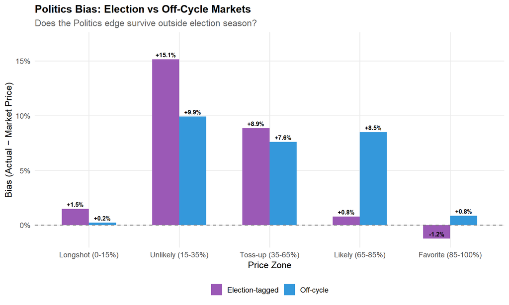

```r
politics_split <- snapshot_data %>%
  filter(snapshot_label == "1d", category == "Politics") %>%
  mutate(
    price_zone  = make_price_zone(snap_price),
    market_type = ifelse(is_election, "Election-tagged", "Off-cycle")
  ) %>%
  group_by(market_type, price_zone) %>%
  summarise(n = n(), bias = mean(yes_resolution) - mean(snap_price), .groups = "drop") %>%
  filter(n >= 10)

ggplot(politics_split, aes(x = price_zone, y = bias, fill = market_type)) +
  geom_col(position = "dodge", width = 0.6) +
  geom_hline(yintercept = 0, linetype = "dashed", color = "grey50") +
  geom_text(aes(label = paste0(ifelse(bias > 0,"+",""), round(bias*100,1),"%")),
            position = position_dodge(width = 0.6), vjust = -0.5, size = 3, fontface = "bold") +
  scale_fill_manual(values = c("Election-tagged" = COL_PURP, "Off-cycle" = COL_BLUE)) +
  scale_y_continuous(labels = percent, expand = expansion(mult = c(0.05, 0.15))) +
  labs(
    title    = "Politics Bias: Election vs Off-Cycle Markets",
    subtitle = "Does the Politics edge survive outside election season?",
    x = "Price Zone", y = "Bias (Actual − Market Price)", fill = NULL
  )
```

```r
politics_agg <- snapshot_data %>%
  filter(snapshot_label == "1d", category == "Politics") %>%
  group_by(market_type = ifelse(is_election, "Election-tagged", "Off-cycle")) %>%
  summarise(
    n_markets       = n(),
    avg_price       = mean(snap_price),
    resolution_rate = mean(yes_resolution),
    bias            = mean(yes_resolution) - mean(snap_price),
    brier_score     = mean((snap_price - yes_resolution)^2),
    .groups         = "drop"
  )

politics_agg %>%
  mutate(across(where(is.numeric), ~ round(.x, 4))) %>%
  knitr::kable(caption = "Politics: Election vs Off-Cycle Bias (1 day before close)")
```

Politics: Election vs Off-Cycle Bias (1 day before close)

| market_type | n_markets | avg_price | resolution_rate | bias | brier_score |
| --- | --- | --- | --- | --- | --- |
| Election-tagged | 4476 | 0.2844 | 0.3213 | 0.0369 | 0.1054 |
| Off-cycle | 5196 | 0.1766 | 0.1940 | 0.0174 | 0.0497 |

# 4 · Volume & Liquidity Analysis

Thin markets are noisier. Let’s check if bias patterns change when we weight by volume, and critically — which edges survive once we filter for markets a bot can actually trade.

## 4.1 Calibration by Volume Tier

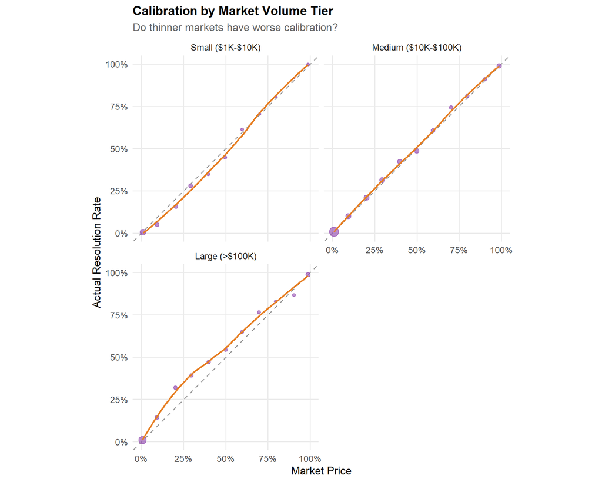

```r
vol_cal <- snapshot_data %>%
  filter(snapshot_label == "1d", !is.na(volume_num)) %>%
  mutate(
    vol_tier = factor(
      case_when(
        volume_num < 1000   ~ "Micro (<$1K)",
        volume_num < 10000  ~ "Small ($1K-$10K)",
        volume_num < 100000 ~ "Medium ($10K-$100K)",
        TRUE                ~ "Large (>$100K)"
      ),
      levels = c("Micro (<$1K)", "Small ($1K-$10K)", "Medium ($10K-$100K)", "Large (>$100K)")
    ),
    price_bin = round(snap_price * 10) / 10
  ) %>%
  group_by(vol_tier, price_bin) %>%
  summarise(n = n(), actual = mean(yes_resolution), predicted = mean(snap_price), .groups = "drop")

ggplot(vol_cal %>% filter(n >= 10), aes(x = predicted, y = actual)) +
  geom_abline(slope = 1, intercept = 0, linetype = "dashed", color = "grey60") +
  geom_point(aes(size = n), color = COL_PURP, alpha = 0.7) +
  geom_smooth(aes(weight = n), method = "loess", se = FALSE, color = COL_ORNG, linewidth = 1) +
  facet_wrap(~ vol_tier, ncol = 2) +
  scale_x_continuous(labels = percent, limits = c(0,1)) +
  scale_y_continuous(labels = percent, limits = c(0,1)) +
  scale_size_continuous(range = c(1,5), guide = "none") +
  coord_equal() +
  labs(
    title    = "Calibration by Market Volume Tier",
    subtitle = "Do thinner markets have worse calibration?",
    x = "Market Price", y = "Actual Resolution Rate"
  )
```

```r
vol_brier <- snapshot_data %>%
  filter(snapshot_label == "1d", !is.na(volume_num)) %>%
  mutate(
    vol_tier = factor(
      case_when(
        volume_num < 1000   ~ "Micro (<$1K)",
        volume_num < 10000  ~ "Small ($1K-$10K)",
        volume_num < 100000 ~ "Medium ($10K-$100K)",
        TRUE                ~ "Large (>$100K)"
      ),
      levels = c("Micro (<$1K)", "Small ($1K-$10K)", "Medium ($10K-$100K)", "Large (>$100K)")
    ),
    brier = (snap_price - yes_resolution)^2
  ) %>%
  group_by(vol_tier) %>%
  summarise(n = n(), brier_score = mean(brier), bias = mean(yes_resolution - snap_price), .groups = "drop")

vol_brier %>%
  mutate(across(where(is.numeric) & !n, ~ round(.x, 4))) %>%
  knitr::kable(caption = "Brier Score & Bias by Volume Tier")
```

Brier Score & Bias by Volume Tier

| vol_tier | n | brier_score | bias |
| --- | --- | --- | --- |
| Small ($1K-$10K) | 8650 | 0.0917 | -0.0188 |
| Medium ($10K-$100K) | 26440 | 0.0958 | 0.0058 |
| Large (>$100K) | 13093 | 0.0872 | 0.0263 |

## 4.2 Liquidity-Filtered Edge Survival

**Critical for bot**: Edges in markets with < $10K volume are un-tradeable (slippage would eat the edge). Here we recompute the exploitable segment table restricted to liquid markets.

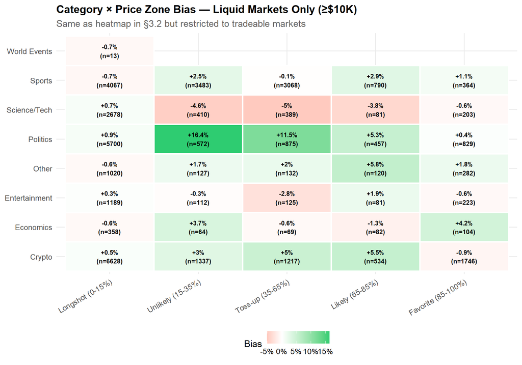

```r
liquid_bias <- snapshot_data %>%
  filter(snapshot_label == "1d", !is.na(volume_num)) %>%
  mutate(
    liquid      = volume_num >= MIN_VOLUME,
    price_zone  = make_price_zone(snap_price)
  )

# Compare bias all vs liquid-only
liquid_compare <- liquid_bias %>%
  group_by(price_zone, liquid) %>%
  summarise(
    n    = n(),
    bias = mean(yes_resolution) - mean(snap_price),
    .groups = "drop"
  ) %>%
  filter(n >= 10) %>%
  mutate(liquid_label = ifelse(liquid, paste0("Liquid (≥$", MIN_VOLUME/1000, "K)"), "All Markets"))

# Category × zone for liquid only
liquid_cat_bias <- liquid_bias %>%
  filter(liquid) %>%
  mutate(price_zone = make_price_zone(snap_price)) %>%
  group_by(category, price_zone) %>%
  summarise(n = n(), bias = mean(yes_resolution) - mean(snap_price), .groups = "drop") %>%
  filter(n >= 10)

ggplot(liquid_cat_bias, aes(x = price_zone, y = category, fill = bias)) +
  geom_tile(color = "white", linewidth = 1) +
  geom_text(aes(label = paste0(ifelse(bias > 0,"+",""), round(bias*100,1),"%\n(n=",n,")")),
            size = 3, fontface = "bold") +
  scale_fill_gradient2(low = COL_NEG, mid = "white", high = COL_POS, midpoint = 0,
                       labels = percent, name = "Bias") +
  labs(
    title    = sprintf("Category × Price Zone Bias — Liquid Markets Only (≥$%dK)", MIN_VOLUME/1000),
    subtitle = "Same as heatmap in §3.2 but restricted to tradeable markets",
    x = NULL, y = NULL
  ) +
  theme(axis.text.x = element_text(angle = 30, hjust = 1))
```

```r
# How many exploitable segments survive the liquidity filter?
all_seg <- snapshot_data %>%
  filter(snapshot_label == "1d") %>%
  mutate(price_zone = make_price_zone(snap_price)) %>%
  group_by(category, price_zone) %>%
  summarise(n = n(), bias = mean(yes_resolution) - mean(snap_price), .groups = "drop") %>%
  filter(n >= MIN_N_EXPLOIT, abs(bias) > 0.03)

liq_seg <- snapshot_data %>%
  filter(snapshot_label == "1d", !is.na(volume_num), volume_num >= MIN_VOLUME) %>%
  mutate(price_zone = make_price_zone(snap_price)) %>%
  group_by(category, price_zone) %>%
  summarise(n = n(), bias = mean(yes_resolution) - mean(snap_price), .groups = "drop") %>%
  filter(n >= MIN_N_EXPLOIT, abs(bias) > 0.03)

cat(sprintf("── Liquidity filter impact ──\n"))
```

```
## ── Liquidity filter impact ──
```

```r
cat(sprintf("  Exploitable segments (all markets):     %d\n", nrow(all_seg)))
```

```
##   Exploitable segments (all markets):     10
```

```r
cat(sprintf("  Exploitable segments (volume ≥ $%dK):   %d\n", MIN_VOLUME/1000, nrow(liq_seg)))
```

```
##   Exploitable segments (volume ≥ $10K):   11
```

```r
cat(sprintf("  Survival rate:                           %.0f%%\n",
            nrow(liq_seg) / max(nrow(all_seg), 1) * 100))
```

```
##   Survival rate:                           110%
```

# 5 · Market Duration Effects

```r
duration_bias <- market_stats %>%
  filter(!is.na(market_duration_h), !is.na(initial_price), market_duration_h >= 1) %>%
  inner_join(
    snapshot_data %>%
      filter(snapshot_label == "1d") %>%
      select(id, snap_price) %>%
      rename(price_1d = snap_price),
    by = "id"
  ) %>%
  mutate(
    duration_tier = factor(
      case_when(
        market_duration_h < 24   ~ "< 1 day",
        market_duration_h < 168  ~ "1-7 days",
        market_duration_h < 720  ~ "1-4 weeks",
        market_duration_h < 2160 ~ "1-3 months",
        TRUE                     ~ "> 3 months"
      ),
      levels = c("< 1 day","1-7 days","1-4 weeks","1-3 months","> 3 months")
    )
  ) %>%
  # Conditional bias within price bins (avoids base-rate contamination)
  mutate(init_bin = round(initial_price * 10) / 10) %>%
  group_by(duration_tier) %>%
  summarise(
    n             = n(),
    init_bias     = mean(yes_resolution - initial_price),
    final_bias    = mean(yes_resolution - price_1d),
    price_range   = mean(price_range, na.rm = TRUE),
    resolution_r  = mean(yes_resolution),
    brier_initial = mean((initial_price - yes_resolution)^2),
    .groups       = "drop"
  )

duration_bias %>%
  mutate(across(where(is.numeric), ~ round(.x, 4))) %>%
  knitr::kable(caption = "Bias & Calibration by Market Duration")
```

Bias & Calibration by Market Duration

| duration_tier | n | init_bias | final_bias | price_range | resolution_r | brier_initial |
| --- | --- | --- | --- | --- | --- | --- |
| < 1 day | 675 | -0.0300 | -0.0300 | 0.4651 | 0.4089 | 0.1925 |
| 1-7 days | 15075 | -0.1312 | 0.0109 | 0.5112 | 0.2825 | 0.2036 |
| 1-4 weeks | 24046 | -0.1422 | 0.0068 | 0.5304 | 0.2810 | 0.2057 |
| 1-3 months | 4915 | -0.2327 | 0.0025 | 0.4973 | 0.1727 | 0.1928 |
| > 3 months | 3472 | -0.2581 | 0.0044 | 0.4753 | 0.1129 | 0.1776 |

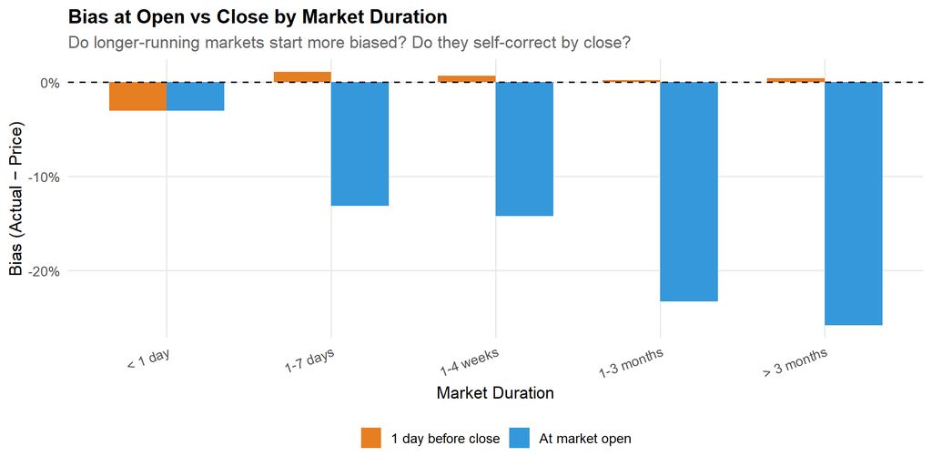

```r
duration_long <- duration_bias %>%
  select(duration_tier, n, init_bias, final_bias) %>%
  pivot_longer(c(init_bias, final_bias), names_to = "stage", values_to = "bias") %>%
  mutate(stage = recode(stage,
    init_bias  = "At market open",
    final_bias = "1 day before close"
  ))

ggplot(duration_long, aes(x = duration_tier, y = bias, fill = stage)) +
  geom_col(position = "dodge", width = 0.7) +
  geom_hline(yintercept = 0, linetype = "dashed") +
  scale_fill_manual(values = c("At market open" = COL_BLUE, "1 day before close" = COL_ORNG)) +
  scale_y_continuous(labels = percent) +
  labs(
    title    = "Bias at Open vs Close by Market Duration",
    subtitle = "Do longer-running markets start more biased? Do they self-correct by close?",
    x = "Market Duration", y = "Bias (Actual − Price)", fill = NULL
  ) +
  theme(axis.text.x = element_text(angle = 20, hjust = 1))
```

# 6 · Late-Stage Price Signals

When the price moves substantially in the final week, is that move informative about the resolution? If yes, **following the move** (momentum) is a tradeable signal. If no (or reverse), **fading the move** is.

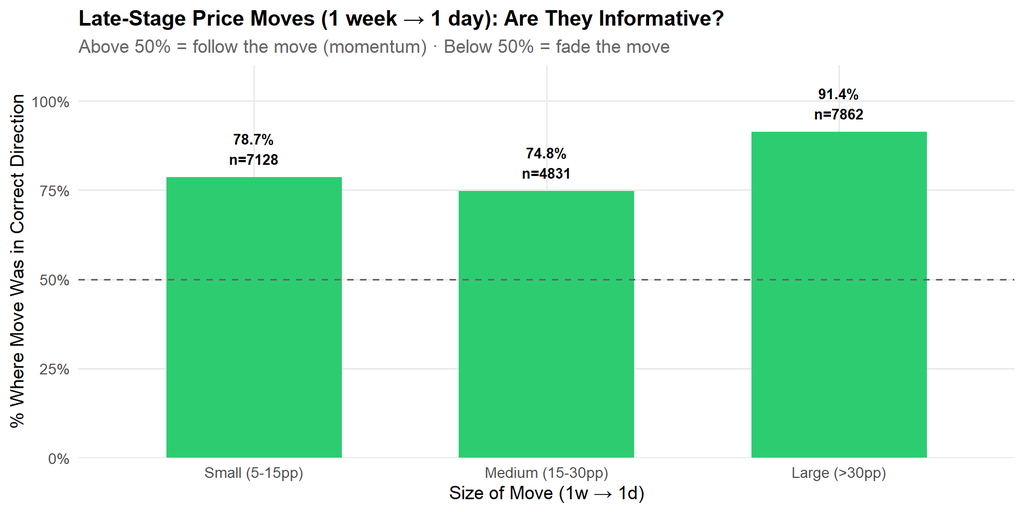

```r
snap_divergence <- snapshot_data %>%
  select(id, snapshot_label, snap_price, yes_resolution, category, volume_num) %>%
  filter(snapshot_label %in% c("1w", "1d")) %>%
  pivot_wider(names_from = snapshot_label, values_from = snap_price,
              names_prefix = "price_") %>%
  filter(!is.na(price_1w), !is.na(price_1d)) %>%
  mutate(
    late_move     = price_1d - price_1w,
    move_correct  = (late_move > 0 & yes_resolution == 1) | (late_move < 0 & yes_resolution == 0),
    move_size_abs = abs(late_move),
    move_bucket   = factor(
      case_when(
        move_size_abs < 0.05 ~ "Tiny (<5pp)",
        move_size_abs < 0.15 ~ "Small (5-15pp)",
        move_size_abs < 0.30 ~ "Medium (15-30pp)",
        TRUE                 ~ "Large (>30pp)"
      ),
      levels = c("Tiny (<5pp)", "Small (5-15pp)", "Medium (15-30pp)", "Large (>30pp)")
    )
  )

late_move_summary <- snap_divergence %>%
  filter(move_size_abs >= 0.05) %>%
  group_by(move_bucket) %>%
  summarise(
    n               = n(),
    pct_correct     = mean(move_correct),
    avg_move        = mean(late_move),
    resolution_rate = mean(yes_resolution),
    .groups         = "drop"
  )

ggplot(late_move_summary, aes(x = move_bucket, y = pct_correct)) +
  geom_col(aes(fill = pct_correct > 0.5), width = 0.6, show.legend = FALSE) +
  geom_hline(yintercept = 0.5, linetype = "dashed", color = "grey40") +
  geom_text(aes(label = paste0(round(pct_correct*100,1),"%\nn=",n)),
            vjust = -0.4, size = 3.5, fontface = "bold") +
  scale_fill_manual(values = c("FALSE" = COL_NEG, "TRUE" = COL_POS)) +
  scale_y_continuous(labels = percent, limits = c(0, 1), expand = expansion(mult = c(0, 0.1))) +
  labs(
    title    = "Late-Stage Price Moves (1 week → 1 day): Are They Informative?",
    subtitle = "Above 50% = follow the move (momentum) · Below 50% = fade the move",
    x = "Size of Move (1w → 1d)", y = "% Where Move Was in Correct Direction"
  )
```

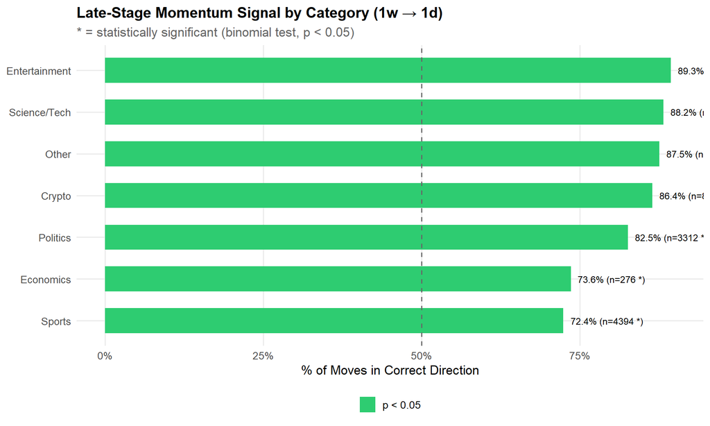

```r
# Statistical test: is the momentum signal significant per category?
late_cat <- snap_divergence %>%
  filter(move_size_abs >= 0.05) %>%
  group_by(category) %>%
  summarise(
    n           = n(),
    pct_correct = mean(move_correct),
    p_value     = if (n() >= 20) binom.test(sum(move_correct), n(), 0.5)$p.value else NA_real_,
    .groups     = "drop"
  ) %>%
  filter(n >= 20) %>%
  mutate(significant = !is.na(p_value) & p_value < 0.05)

ggplot(late_cat, aes(x = reorder(category, pct_correct), y = pct_correct)) +
  geom_col(aes(fill = significant), width = 0.6) +
  geom_hline(yintercept = 0.5, linetype = "dashed", color = "grey40") +
  geom_text(aes(label = paste0(round(pct_correct*100,1),"% (n=",n,
                                ifelse(significant, " *", ""), ")")),
            hjust = -0.1, size = 3.3) +
  scale_fill_manual(values = c("FALSE" = COL_NEUT, "TRUE" = COL_POS),
                    labels = c("FALSE" = "Not significant", "TRUE" = "p < 0.05")) +
  scale_y_continuous(labels = percent, limits = c(0, 0.9)) +
  coord_flip() +
  labs(
    title    = "Late-Stage Momentum Signal by Category (1w → 1d)",
    subtitle = "* = statistically significant (binomial test, p < 0.05)",
    x = NULL, y = "% of Moves in Correct Direction", fill = NULL
  )
```

# 7 · Temporal Stability of Edges

**Critical for bot**: A bias that appeared once is noise; a bias that persists monthly is structural. Here we track the top exploitable segments over time to see which edges a bot can rely on.

```r
# Add close month to snapshot data
snap_with_time <- snapshot_data %>%
  filter(snapshot_label == "1d") %>%
  left_join(
    market_stats %>% select(id, closed_dt),
    by = "id"
  ) %>%
  filter(!is.na(closed_dt)) %>%
  mutate(
    close_month   = floor_date(closed_dt, "month"),
    close_quarter = paste0(year(closed_dt), "-Q", quarter(closed_dt)),
    price_zone    = make_price_zone(snap_price)
  )
```

## 7.1 Rolling Monthly Bias for Top Segments

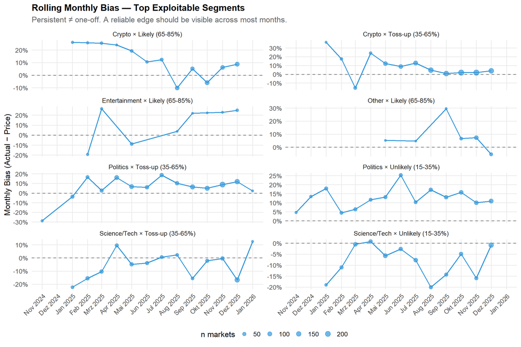

```r
# Identify the top exploitable segments (from all-data analysis)
top_segments <- snapshot_data %>%
  filter(snapshot_label == "1d") %>%
  mutate(price_zone = make_price_zone(snap_price)) %>%
  group_by(category, price_zone) %>%
  summarise(n = n(), bias = mean(yes_resolution) - mean(snap_price), .groups = "drop") %>%
  filter(n >= 30, abs(bias) > 0.04) %>%
  slice_max(abs(bias), n = 8) %>%
  mutate(segment = paste(category, "×", price_zone))

# Monthly bias for these segments
monthly_bias <- snap_with_time %>%
  mutate(segment = paste(category, "×", price_zone)) %>%
  filter(segment %in% top_segments$segment) %>%
  group_by(segment, close_month) %>%
  summarise(
    n    = n(),
    bias = mean(yes_resolution) - mean(snap_price),
    .groups = "drop"
  ) %>%
  filter(n >= 5)   # need at least 5 markets per month to be meaningful

if (nrow(monthly_bias) > 0) {
  ggplot(monthly_bias, aes(x = close_month, y = bias)) +
    geom_hline(yintercept = 0, linetype = "dashed", color = "grey50") +
    geom_line(color = COL_BLUE, linewidth = 0.8) +
    geom_point(aes(size = n), color = COL_BLUE, alpha = 0.7) +
    facet_wrap(~ segment, ncol = 2, scales = "free_y") +
    scale_x_datetime(date_labels = "%b %Y", date_breaks = "1 month") +
    scale_y_continuous(labels = percent) +
    scale_size_continuous(range = c(1.5, 4), name = "n markets") +
    labs(
      title    = "Rolling Monthly Bias — Top Exploitable Segments",
      subtitle = "Persistent ≠ one-off. A reliable edge should be visible across most months.",
      x = NULL, y = "Monthly Bias (Actual − Price)"
    ) +
    theme(axis.text.x = element_text(angle = 45, hjust = 1))
} else {
  cat("Not enough data for monthly segment breakdown.\n")
}
```

## 7.2 Edge Persistence Score

```r
# For each top segment: in how many months was the bias in the "expected" direction?
persistence <- snap_with_time %>%
  mutate(segment = paste(category, "×", price_zone)) %>%
  filter(segment %in% top_segments$segment) %>%
  group_by(segment, close_month) %>%
  summarise(
    n            = n(),
    monthly_bias = mean(yes_resolution) - mean(snap_price),
    .groups      = "drop"
  ) %>%
  filter(n >= 5) %>%
  left_join(top_segments %>% select(segment, bias), by = "segment") %>%
  rename(overall_bias = bias) %>%
  mutate(same_direction = sign(monthly_bias) == sign(overall_bias)) %>%
  group_by(segment, overall_bias) %>%
  summarise(
    n_months        = n(),
    months_correct  = sum(same_direction),
    persistence_pct = mean(same_direction) * 100,
    avg_monthly_n   = mean(n),
    .groups         = "drop"
  ) %>%
  arrange(desc(persistence_pct))

persistence %>%
  mutate(
    overall_bias    = paste0(round(overall_bias * 100, 1), "%"),
    persistence_pct = paste0(round(persistence_pct, 0), "%"),
    avg_monthly_n   = round(avg_monthly_n, 0)
  ) %>%
  knitr::kable(caption = "Edge Persistence: How Many Months Does the Bias Appear?")
```

Edge Persistence: How Many Months Does the Bias Appear?

| segment | overall_bias | n_months | months_correct | persistence_pct | avg_monthly_n |
| --- | --- | --- | --- | --- | --- |
| Politics × Unlikely (15-35%) | 12.9% | 14 | 14 | 100% | 52 |
| Crypto × Toss-up (35-65%) | 4.6% | 12 | 11 | 92% | 111 |
| Science/Tech × Unlikely (15-35%) | -6.2% | 12 | 11 | 92% | 68 |
| Politics × Toss-up (35-65%) | 8.4% | 14 | 12 | 86% | 83 |
| Crypto × Likely (65-85%) | 4.8% | 12 | 10 | 83% | 46 |
| Other × Likely (65-85%) | 4.9% | 6 | 5 | 83% | 26 |
| Entertainment × Likely (65-85%) | 5% | 8 | 6 | 75% | 10 |
| Science/Tech × Toss-up (35-65%) | -7.7% | 13 | 9 | 69% | 52 |

## 7.3 Is the Market Getting More Efficient?

```r
quarterly_cal <- snap_with_time %>%
  group_by(close_quarter) %>%
  summarise(
    n           = n(),
    bias        = mean(yes_resolution - snap_price),
    brier_score = mean((snap_price - yes_resolution)^2),
    abs_bias    = mean(abs(yes_resolution - snap_price)),
    .groups     = "drop"
  )

quarterly_cal %>%
  mutate(across(where(is.numeric) & !n, ~ round(.x, 4))) %>%
  knitr::kable(caption = "Calibration by Quarter — Is the market getting more efficient over time?")
```

Calibration by Quarter — Is the market getting more efficient over time?

| close_quarter | n | bias | brier_score | abs_bias |
| --- | --- | --- | --- | --- |
| 2024-Q2 | 6 | -0.0049 | 0.1711 | 0.2949 |
| 2024-Q3 | 9 | -0.0814 | 0.0419 | 0.0873 |
| 2024-Q4 | 350 | -0.0285 | 0.0513 | 0.1089 |
| 2025-Q1 | 5128 | 0.0008 | 0.0892 | 0.1770 |
| 2025-Q2 | 7207 | 0.0071 | 0.0889 | 0.1791 |
| 2025-Q3 | 10434 | 0.0079 | 0.0966 | 0.1923 |
| 2025-Q4 | 23703 | 0.0091 | 0.0980 | 0.1945 |
| 2026-Q1 | 1346 | -0.0060 | 0.0141 | 0.0309 |

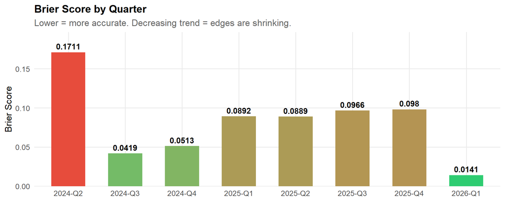

```r
if (nrow(quarterly_cal) >= 2) {
  ggplot(quarterly_cal, aes(x = close_quarter, y = brier_score)) +
    geom_col(aes(fill = brier_score), width = 0.6, show.legend = FALSE) +
    geom_text(aes(label = round(brier_score, 4)), vjust = -0.5, fontface = "bold", size = 4) +
    scale_fill_gradient(low = COL_POS, high = COL_NEG) +
    scale_y_continuous(expand = expansion(mult = c(0, 0.15))) +
    labs(
      title    = "Brier Score by Quarter",
      subtitle = "Lower = more accurate. Decreasing trend = edges are shrinking.",
      x = NULL, y = "Brier Score"
    )
}
```

# 8 · Exploitable Pattern Summary

## 8.1 Gross Edge Table

```r
exploitable <- snapshot_data %>%
  filter(snapshot_label == "1d") %>%
  mutate(price_zone = make_price_zone(snap_price)) %>%
  group_by(category, price_zone) %>%
  summarise(
    n_markets   = n(),
    avg_price   = mean(snap_price),
    actual_rate = mean(yes_resolution),
    bias        = mean(yes_resolution) - mean(snap_price),
    edge_pct    = bias / avg_price * 100,
    brier       = mean((snap_price - yes_resolution)^2),
    .groups     = "drop"
  ) %>%
  filter(n_markets >= MIN_N_EXPLOIT, abs(bias) > 0.03) %>%
  arrange(desc(abs(bias)))

exploitable %>%
  mutate(across(where(is.numeric) & !n_markets, ~ round(.x, 3))) %>%
  head(20) %>%
  knitr::kable(caption = "Top 20 Most Exploitable Category × Price Zone Combinations (|bias| > 3%, n ≥ 15)")
```

Top 20 Most Exploitable Category × Price Zone Combinations (|bias| > 3%, n ≥ 15)

| category | price_zone | n_markets | avg_price | actual_rate | bias | edge_pct | brier |
| --- | --- | --- | --- | --- | --- | --- | --- |
| Politics | Unlikely (15-35%) | 731 | 0.253 | 0.382 | 0.129 | 51.071 | 0.247 |
| Politics | Toss-up (35-65%) | 1170 | 0.502 | 0.586 | 0.084 | 16.802 | 0.247 |
| Science/Tech | Toss-up (35-65%) | 678 | 0.465 | 0.388 | -0.077 | -16.506 | 0.232 |
| Science/Tech | Unlikely (15-35%) | 822 | 0.251 | 0.189 | -0.062 | -24.751 | 0.155 |
| Entertainment | Likely (65-85%) | 93 | 0.756 | 0.806 | 0.050 | 6.656 | 0.152 |
| Other | Likely (65-85%) | 174 | 0.761 | 0.810 | 0.049 | 6.471 | 0.156 |
| Crypto | Likely (65-85%) | 557 | 0.751 | 0.799 | 0.048 | 6.371 | 0.164 |
| Crypto | Toss-up (35-65%) | 1331 | 0.482 | 0.527 | 0.046 | 9.444 | 0.243 |
| Economics | Favorite (85-100%) | 116 | 0.945 | 0.983 | 0.038 | 3.976 | 0.019 |
| Politics | Likely (65-85%) | 615 | 0.749 | 0.782 | 0.033 | 4.470 | 0.169 |

## 8.2 Transaction Cost–Adjusted Edge Table

**The critical filter**: gross edges are meaningless without accounting for the ~2% spread and ~2% winner fee. A segment is only tradeable if the net edge after costs exceeds ~1%.

```r
exploitable_net <- exploitable %>%
  mutate(
    strategy   = ifelse(bias > 0, "Buy Yes", "Buy No"),
    # Win probability and price depend on which side we're trading
    win_prob   = ifelse(bias > 0, actual_rate, 1 - actual_rate),
    entry_price = ifelse(bias > 0, avg_price, 1 - avg_price),
    # Costs
    spread     = SPREAD_COST,
    fee_cost   = WINNER_FEE * win_prob,   # fee only applies to wins
    total_cost = spread + fee_cost,
    # Net edge after costs
    gross_edge = abs(bias),
    net_edge   = gross_edge - total_cost,
    # Expected P&L per $1 bet (accounting for costs)
    gross_pl   = ifelse(
      bias > 0,
      actual_rate * (1 / avg_price - 1) - (1 - actual_rate),
      (1 - actual_rate) * (1 / (1 - avg_price) - 1) - actual_rate
    ),
    net_pl     = gross_pl - total_cost,
    tradeable  = net_edge > MIN_EDGE_NET
  ) %>%
  arrange(desc(net_edge))

exploitable_net %>%
  select(category, price_zone, n_markets, strategy, gross_edge, spread,
         fee_cost, total_cost, net_edge, net_pl, tradeable) %>%
  mutate(
    across(c(gross_edge, spread, fee_cost, total_cost, net_edge, net_pl),
           ~ paste0(round(.x * 100, 1), "%")),
    tradeable = ifelse(tradeable, "✅ YES", "❌ NO")
  ) %>%
  head(20) %>%
  knitr::kable(
    caption = sprintf("Cost-Adjusted Edges (spread=%.0f%%, winner fee=%.0f%%, min net edge=%.0f%%)",
                      SPREAD_COST*100, WINNER_FEE*100, MIN_EDGE_NET*100)
  )
```

Cost-Adjusted Edges (spread=2%, winner fee=2%, min net edge=1%)

| category | price_zone | n_markets | strategy | gross_edge | spread | fee_cost | total_cost | net_edge | net_pl | tradeable |
| --- | --- | --- | --- | --- | --- | --- | --- | --- | --- | --- |
| Politics | Unlikely (15-35%) | 731 | Buy Yes | 12.9% | 2% | 0.8% | 2.8% | 10.1% | 48.3% | ✅ YES |
| Politics | Toss-up (35-65%) | 1170 | Buy Yes | 8.4% | 2% | 1.2% | 3.2% | 5.3% | 13.6% | ✅ YES |
| Science/Tech | Toss-up (35-65%) | 678 | Buy No | 7.7% | 2% | 1.2% | 3.2% | 4.4% | 11.1% | ✅ YES |
| Science/Tech | Unlikely (15-35%) | 822 | Buy No | 6.2% | 2% | 1.6% | 3.6% | 2.6% | 4.7% | ✅ YES |
| Crypto | Toss-up (35-65%) | 1331 | Buy Yes | 4.6% | 2% | 1.1% | 3.1% | 1.5% | 6.4% | ✅ YES |
| Entertainment | Likely (65-85%) | 93 | Buy Yes | 5% | 2% | 1.6% | 3.6% | 1.4% | 3% | ✅ YES |
| Other | Likely (65-85%) | 174 | Buy Yes | 4.9% | 2% | 1.6% | 3.6% | 1.3% | 2.9% | ✅ YES |
| Crypto | Likely (65-85%) | 557 | Buy Yes | 4.8% | 2% | 1.6% | 3.6% | 1.2% | 2.8% | ✅ YES |
| Economics | Favorite (85-100%) | 116 | Buy Yes | 3.8% | 2% | 2% | 4% | -0.2% | 0% | ❌ NO |
| Politics | Likely (65-85%) | 615 | Buy Yes | 3.3% | 2% | 1.6% | 3.6% | -0.2% | 0.9% | ❌ NO |

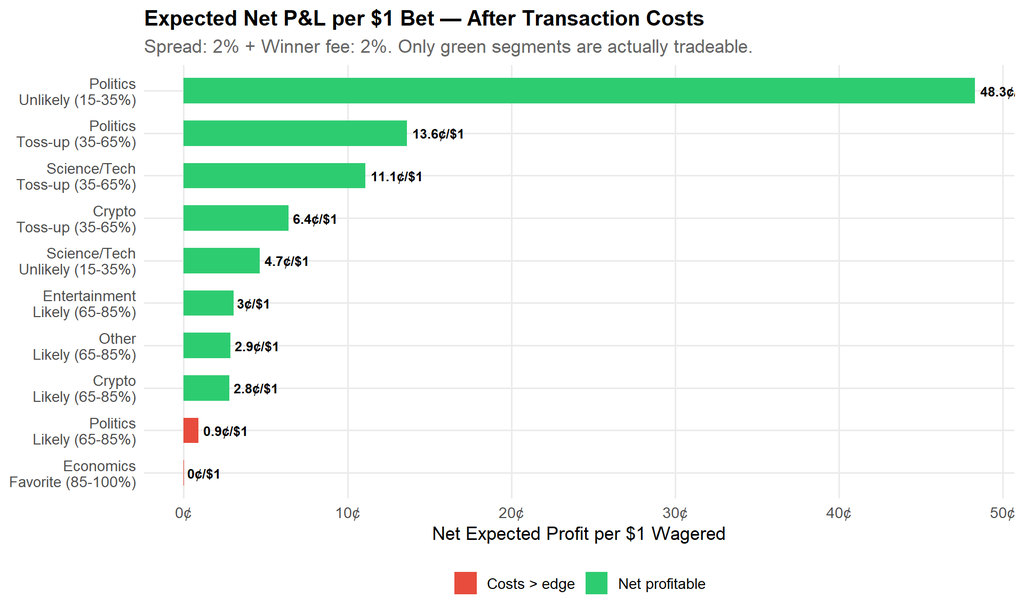

```r
plot_data <- exploitable_net %>%
  head(15) %>%
  mutate(label = paste(category, price_zone, sep = "\n"))

ggplot(plot_data, aes(x = reorder(label, net_pl), y = net_pl)) +
  geom_col(aes(fill = tradeable), width = 0.6) +
  geom_text(aes(label = paste0(round(net_pl*100,1), "¢/$1")),
            hjust = ifelse(plot_data$net_pl >= 0, -0.1, 1.1),
            size = 3.3, fontface = "bold") +
  scale_fill_manual(values = c("TRUE" = COL_POS, "FALSE" = COL_NEG),
                    labels = c("TRUE" = "Net profitable", "FALSE" = "Costs > edge")) +
  scale_y_continuous(labels = function(x) paste0(round(x*100,1),"¢")) +
  coord_flip() +
  labs(
    title    = "Expected Net P&L per $1 Bet — After Transaction Costs",
    subtitle = sprintf("Spread: %.0f%% + Winner fee: %.0f%%. Only green segments are actually tradeable.",
                       SPREAD_COST*100, WINNER_FEE*100),
    x = NULL, y = "Net Expected Profit per $1 Wagered", fill = NULL
  )
```

```r
n_gross    <- nrow(exploitable)
n_tradeable <- sum(exploitable_net$tradeable, na.rm = TRUE)
cat(sprintf("── Cost filter impact ──\n"))
```

```
## ── Cost filter impact ──
```

```r
cat(sprintf("  Segments with gross |bias| > 3%%:   %d\n", n_gross))
```

```
##   Segments with gross |bias| > 3%:   10
```

```r
cat(sprintf("  Segments profitable after costs:    %d\n", n_tradeable))
```

```
##   Segments profitable after costs:    8
```

```r
cat(sprintf("  Kill rate:                           %.0f%%\n",
            (1 - n_tradeable / max(n_gross, 1)) * 100))
```

```
##   Kill rate:                           20%
```

## 8.3 Bootstrap Confidence Intervals

```r
snap_1d <- snapshot_data %>%
  filter(snapshot_label == "1d") %>%
  mutate(price_zone = make_price_zone(snap_price))

boot_bias_fn <- function(data, indices) {
  d <- data[indices, ]
  mean(d$yes_resolution) - mean(d$snap_price)
}

# Bootstrap the tradeable (or top) segments
top_for_ci <- exploitable_net %>% head(15) %>% select(category, price_zone)

ci_results <- pmap_dfr(top_for_ci, function(category, price_zone) {
  seg <- snap_1d %>% filter(category == .env$category, price_zone == .env$price_zone)
  n_obs      <- nrow(seg)
  point_bias <- mean(seg$yes_resolution) - mean(seg$snap_price)

  ci_lo <- NA_real_
  ci_hi <- NA_real_

  if (n_obs >= 30) {
    bo <- boot(seg, boot_bias_fn, R = 2000)
    ci <- boot.ci(bo, type = "perc")
    if (!is.null(ci$percent)) {
      ci_lo <- ci$percent[4]
      ci_hi <- ci$percent[5]
    }
  }

  tibble(
    category    = category,
    price_zone  = price_zone,
    n_obs       = n_obs,
    point_bias  = point_bias,
    ci_lo       = ci_lo,
    ci_hi       = ci_hi,
    significant = !is.na(ci_lo) & (ci_lo > 0 | ci_hi < 0)
  )
})

ci_results %>%
  mutate(
    across(c(point_bias, ci_lo, ci_hi), ~ paste0(round(.x * 100, 2), "%")),
    significant = ifelse(significant, "✅ YES", "no")
  ) %>%
  knitr::kable(caption = "Bootstrap 95% CIs — Which Edges Are Statistically Real?")
```

Bootstrap 95% CIs — Which Edges Are Statistically Real?

| category | price_zone | n_obs | point_bias | ci_lo | ci_hi | significant |
| --- | --- | --- | --- | --- | --- | --- |
| Politics | Unlikely (15-35%) | 731 | 12.9% | 9.44% | 16.29% | ✅ YES |
| Politics | Toss-up (35-65%) | 1170 | 8.43% | 5.68% | 11.34% | ✅ YES |
| Science/Tech | Toss-up (35-65%) | 678 | -7.67% | -11.19% | -4.18% | ✅ YES |
| Science/Tech | Unlikely (15-35%) | 822 | -6.2% | -8.88% | -3.55% | ✅ YES |
| Crypto | Toss-up (35-65%) | 1331 | 4.55% | 2.05% | 7.21% | ✅ YES |
| Entertainment | Likely (65-85%) | 93 | 5.03% | -2.58% | 12.48% | no |
| Other | Likely (65-85%) | 174 | 4.93% | -1.04% | 10.5% | no |
| Crypto | Likely (65-85%) | 557 | 4.79% | 1.46% | 7.93% | ✅ YES |
| Economics | Favorite (85-100%) | 116 | 3.76% | 1.02% | 5.84% | ✅ YES |
| Politics | Likely (65-85%) | 615 | 3.35% | 0.18% | 6.49% | ✅ YES |

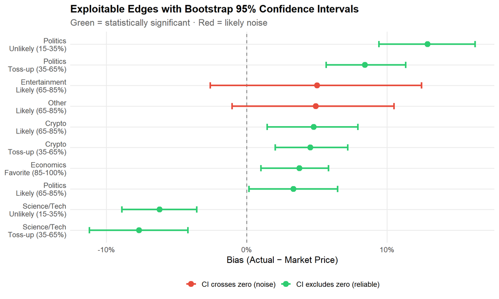

```r
ci_plot <- ci_results %>%
  filter(!is.na(ci_lo)) %>%
  mutate(label = paste(category, price_zone, sep = "\n"))

ggplot(ci_plot, aes(x = reorder(label, point_bias), y = point_bias)) +
  geom_hline(yintercept = 0, linetype = "dashed", color = "grey50") +
  geom_errorbar(aes(ymin = ci_lo, ymax = ci_hi, color = significant),
                width = 0.3, linewidth = 1.2) +
  geom_point(aes(color = significant), size = 3.5) +
  scale_color_manual(
    values = c("TRUE" = COL_POS, "FALSE" = COL_NEG),
    labels = c("TRUE" = "CI excludes zero (reliable)", "FALSE" = "CI crosses zero (noise)")
  ) +
  scale_y_continuous(labels = percent) +
  coord_flip() +
  labs(
    title    = "Exploitable Edges with Bootstrap 95% Confidence Intervals",
    subtitle = "Green = statistically significant · Red = likely noise",
    x = NULL, y = "Bias (Actual − Market Price)", color = NULL
  )
```

## 8.4 Kelly Criterion Position Sizing

For each tradeable edge, optimal bet sizing via the Kelly criterion. Half-Kelly is recommended in practice (accounts for edge estimation error).

```r
kelly_table <- exploitable_net %>%
  filter(tradeable) %>%
  mutate(
    # For a binary bet: Kelly f* = (p*b - q) / b
    # where p = win prob, q = 1-p, b = net payout odds
    # On Polymarket: if entry price = c, payout = 1, so b = (1-cost)/c - 1 roughly
    # Simplified: edge / variance approach
    # f* = net_edge / (entry_price * (1 - entry_price))  (approx for binary)
    b           = (1 - total_cost) / entry_price - 1,   # net payout ratio
    q           = 1 - win_prob,
    kelly_full  = pmax(0, (win_prob * b - q) / b),
    kelly_half  = kelly_full / 2,
    # Expected log growth at half-Kelly
    growth_rate = win_prob * log(1 + kelly_half * b) + q * log(1 - kelly_half)
  ) %>%
  select(category, price_zone, strategy, n_markets, net_edge, win_prob,
         kelly_full, kelly_half, growth_rate) %>%
  arrange(desc(growth_rate))

kelly_table %>%
  mutate(
    net_edge    = paste0(round(net_edge * 100, 1), "%"),
    win_prob    = paste0(round(win_prob * 100, 1), "%"),
    kelly_full  = paste0(round(kelly_full * 100, 1), "%"),
    kelly_half  = paste0(round(kelly_half * 100, 1), "%"),
    growth_rate = paste0(round(growth_rate * 100, 3), "%")
  ) %>%
  knitr::kable(caption = "Kelly Criterion Sizing — Tradeable Segments Only (after costs)")
```

Kelly Criterion Sizing — Tradeable Segments Only (after costs)

| category | price_zone | strategy | n_markets | net_edge | win_prob | kelly_full | kelly_half | growth_rate |
| --- | --- | --- | --- | --- | --- | --- | --- | --- |
| Politics | Unlikely (15-35%) | Buy Yes | 731 | 10.1% | 38.2% | 16.5% | 8.2% | 2.729% |
| Politics | Toss-up (35-65%) | Buy Yes | 1170 | 5.3% | 58.6% | 14.1% | 7% | 0.695% |
| Science/Tech | Toss-up (35-65%) | Buy No | 678 | 4.4% | 61.2% | 13.2% | 6.6% | 0.529% |
| Science/Tech | Unlikely (15-35%) | Buy No | 822 | 2.6% | 81.1% | 15.2% | 7.6% | 0.255% |
| Crypto | Toss-up (35-65%) | Buy Yes | 1331 | 1.5% | 52.7% | 6% | 3% | 0.138% |
| Entertainment | Likely (65-85%) | Buy Yes | 93 | 1.4% | 80.6% | 10.2% | 5.1% | 0.109% |
| Other | Likely (65-85%) | Buy Yes | 174 | 1.3% | 81% | 9.8% | 4.9% | 0.098% |
| Crypto | Likely (65-85%) | Buy Yes | 557 | 1.2% | 79.9% | 9% | 4.5% | 0.087% |

## 8.5 Composite Exploitability Score

A single score the bot can compute in real-time for any market. Combines calibration bias, liquidity, statistical significance, and temporal persistence.

```r
# Build a scoring table for each tradeable segment
composite <- exploitable_net %>%
  filter(tradeable) %>%
  mutate(segment = paste(category, "×", price_zone)) %>%
  left_join(
    ci_results %>% select(category, price_zone, significant, ci_lo, ci_hi),
    by = c("category", "price_zone")
  ) %>%
  left_join(
    persistence %>% select(segment, persistence_pct, n_months),
    by = "segment"
  ) %>%
  mutate(
    # Build the composite
    segment = paste(category, "×", price_zone),
    # Component scores (0-1)
    edge_score       = pmin(abs(net_edge) / 0.10, 1),               # net edge scaled to 10%
    stat_score       = ifelse(significant, 1, 0),                    # binary: CI excludes 0?
    persist_score    = coalesce(persistence_pct / 100, 0.5),         # % of months bias persists
    sample_score     = pmin(n_markets / 500, 1),                     # scaled sample size
    # Weighted composite
    composite_score  = 0.35 * edge_score +
                       0.25 * stat_score +
                       0.25 * persist_score +
                       0.15 * sample_score
  ) %>%
  arrange(desc(composite_score))

composite %>%
  select(segment, strategy, net_edge, edge_score, stat_score, persist_score,
         sample_score, composite_score) %>%
  mutate(
    net_edge = paste0(round(net_edge * 100, 1), "%"),
    across(c(edge_score, stat_score, persist_score, sample_score, composite_score),
           ~ round(.x, 2))
  ) %>%
  knitr::kable(
    caption = "Composite Exploitability Score (0-1) — Higher = more reliably tradeable"
  )
```

Composite Exploitability Score (0-1) — Higher = more reliably tradeable

| segment | strategy | net_edge | edge_score | stat_score | persist_score | sample_score | composite_score |
| --- | --- | --- | --- | --- | --- | --- | --- |
| Politics × Unlikely (15-35%) | Buy Yes | 10.1% | 1.00 | 1 | 1.00 | 1.00 | 1.00 |
| Politics × Toss-up (35-65%) | Buy Yes | 5.3% | 0.53 | 1 | 0.86 | 1.00 | 0.80 |
| Science/Tech × Toss-up (35-65%) | Buy No | 4.4% | 0.44 | 1 | 0.69 | 1.00 | 0.73 |
| Science/Tech × Unlikely (15-35%) | Buy No | 2.6% | 0.26 | 1 | 0.92 | 1.00 | 0.72 |
| Crypto × Toss-up (35-65%) | Buy Yes | 1.5% | 0.15 | 1 | 0.92 | 1.00 | 0.68 |
| Crypto × Likely (65-85%) | Buy Yes | 1.2% | 0.12 | 1 | 0.83 | 1.00 | 0.65 |
| Other × Likely (65-85%) | Buy Yes | 1.3% | 0.13 | 0 | 0.83 | 0.35 | 0.31 |
| Entertainment × Likely (65-85%) | Buy Yes | 1.4% | 0.14 | 0 | 0.75 | 0.19 | 0.27 |

# 9 · Simulated Backtest

**The ultimate test**: if we had traded every qualifying market in the exploitable segments, what would the P&L look like?

```r
# Identify all markets in tradeable segments, using 1d snapshot as entry
tradeable_segments <- exploitable_net %>%
  filter(tradeable) %>%
  select(category, price_zone, strategy)

backtest_markets <- snapshot_data %>%
  filter(snapshot_label == "1d") %>%
  mutate(price_zone = make_price_zone(snap_price)) %>%
  inner_join(tradeable_segments, by = c("category", "price_zone")) %>%
  left_join(market_stats %>% select(id, closed_dt), by = "id") %>%
  filter(!is.na(closed_dt)) %>%
  arrange(closed_dt) %>%
  mutate(
    # Entry price and resolution
    entry_price = ifelse(strategy == "Buy Yes", snap_price, 1 - snap_price),
    won         = ifelse(strategy == "Buy Yes", yes_resolution == 1, yes_resolution == 0),
    # P&L per $1 bet
    gross_pnl   = ifelse(won, (1 - entry_price), -entry_price),
    # Costs: spread on entry, fee on win
    cost        = SPREAD_COST + ifelse(won, WINNER_FEE, 0),
    net_pnl     = gross_pnl - cost,
    # Cumulative
    cum_gross   = cumsum(gross_pnl),
    cum_net     = cumsum(net_pnl),
    bet_num     = row_number()
  )

cat(sprintf("── Backtest universe ──\n"))
```

```
## ── Backtest universe ──
```

```r
cat(sprintf("  Tradeable segments:  %d\n", nrow(tradeable_segments)))
```

```
##   Tradeable segments:  8
```

```r
cat(sprintf("  Total qualifying bets: %d\n", nrow(backtest_markets)))
```

```
##   Total qualifying bets: 5556
```

```r
cat(sprintf("  Win rate:              %.1f%%\n", mean(backtest_markets$won) * 100))
```

```
##   Win rate:              61.4%
```

```r
cat(sprintf("  Gross P&L (total):     $%.2f per $1/bet\n", sum(backtest_markets$gross_pnl)))
```

```
##   Gross P&L (total):     $396.46 per $1/bet
```

```r
cat(sprintf("  Net P&L (total):       $%.2f per $1/bet\n", sum(backtest_markets$net_pnl)))
```

```
##   Net P&L (total):       $217.14 per $1/bet
```

```r
cat(sprintf("  Net P&L per bet:       %.2f¢\n", mean(backtest_markets$net_pnl) * 100))
```

```
##   Net P&L per bet:       3.91¢
```

## 9.1 Cumulative P&L

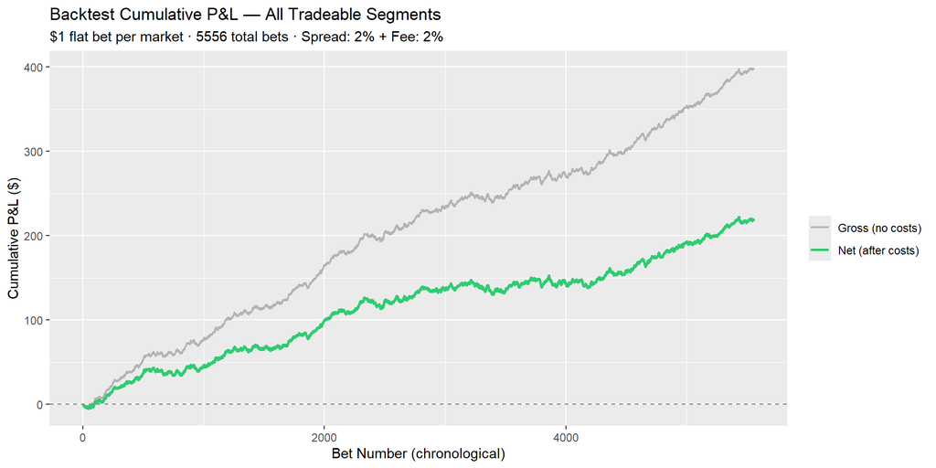

```r
ggplot(backtest_markets, aes(x = bet_num)) +
  geom_line(aes(y = cum_gross, color = "Gross (no costs)"), linewidth = 0.8) +
  geom_line(aes(y = cum_net, color = "Net (after costs)"), linewidth = 1) +
  geom_hline(yintercept = 0, linetype = "dashed", color = "grey50") +
  scale_color_manual(values = c("Gross (no costs)" = COL_NEUT, "Net (after costs)" = COL_POS)) +
  labs(
    title    = "Backtest Cumulative P&L — All Tradeable Segments",
    subtitle = sprintf("$1 flat bet per market · %d total bets · Spread: %.0f%% + Fee: %.0f%%",
                       nrow(backtest_markets), SPREAD_COST*100, WINNER_FEE*100),
    x = "Bet Number (chronological)", y = "Cumulative P&L ($)", color = NULL
  )
```

## 9.2 Drawdown & Risk Metrics

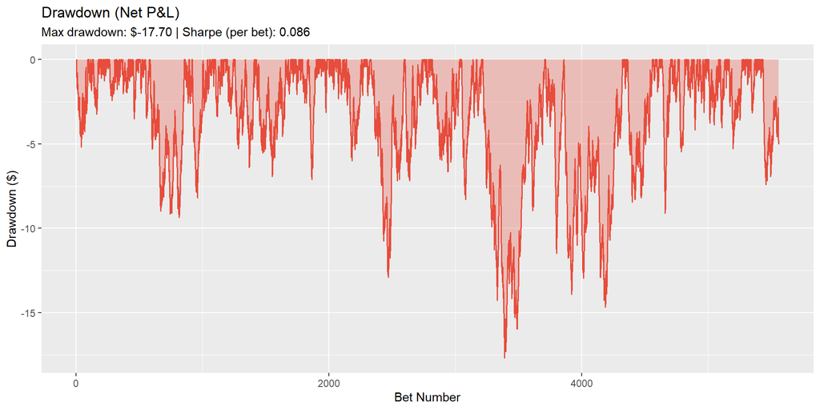

```r
# Compute drawdown
backtest_markets <- backtest_markets %>%
  mutate(
    peak_net  = cummax(cum_net),
    drawdown  = cum_net - peak_net
  )

max_dd     <- min(backtest_markets$drawdown)
total_bets <- nrow(backtest_markets)
total_net  <- sum(backtest_markets$net_pnl)
avg_net    <- mean(backtest_markets$net_pnl)
sd_net     <- sd(backtest_markets$net_pnl)
sharpe_per_bet <- avg_net / sd_net  # per-bet Sharpe analog

ggplot(backtest_markets, aes(x = bet_num, y = drawdown)) +
  geom_area(fill = COL_NEG, alpha = 0.3) +
  geom_line(color = COL_NEG, linewidth = 0.6) +
  labs(
    title    = "Drawdown (Net P&L)",
    subtitle = sprintf("Max drawdown: $%.2f | Sharpe (per bet): %.3f", max_dd, sharpe_per_bet),
    x = "Bet Number", y = "Drawdown ($)"
  )
```

```r
# Monthly returns
monthly_bt <- backtest_markets %>%
  mutate(month = floor_date(closed_dt, "month")) %>%
  group_by(month) %>%
  summarise(
    n_bets     = n(),
    net_pnl    = sum(net_pnl),
    win_rate   = mean(won),
    .groups    = "drop"
  )

tibble(
  Metric = c("Total bets", "Win rate", "Gross P&L", "Net P&L",
             "Net P&L per bet", "Std dev per bet", "Sharpe (per bet)",
             "Max drawdown", "Profitable months"),
  Value = c(
    total_bets,
    paste0(round(mean(backtest_markets$won)*100, 1), "%"),
    paste0("$", round(sum(backtest_markets$gross_pnl), 2)),
    paste0("$", round(total_net, 2)),
    paste0(round(avg_net*100, 2), "¢"),
    paste0(round(sd_net*100, 2), "¢"),
    round(sharpe_per_bet, 3),
    paste0("$", round(max_dd, 2)),
    paste0(sum(monthly_bt$net_pnl > 0), "/", nrow(monthly_bt))
  )
) %>%
  knitr::kable(caption = "Backtest Summary — Flat $1 Bets on All Tradeable Segments")
```

Backtest Summary — Flat $1 Bets on All Tradeable Segments

[output not shown]

[figure not shown]

```r
if (nrow(monthly_bt) >= 2) {
  ggplot(monthly_bt, aes(x = month, y = net_pnl)) +
    geom_col(aes(fill = net_pnl > 0), width = 25, show.legend = FALSE) +
    geom_hline(yintercept = 0, linetype = "dashed") +
    geom_text(aes(label = paste0("$", round(net_pnl, 1))), vjust = -0.5, size = 3) +
    scale_fill_manual(values = c("FALSE" = COL_NEG, "TRUE" = COL_POS)) +
    labs(
      title = "Monthly Net P&L",
      subtitle = "Consistency across months = structural edge; one big month = lucky",
      x = NULL, y = "Net P&L ($)"
    )
}
```

## 9.3 P&L by Segment

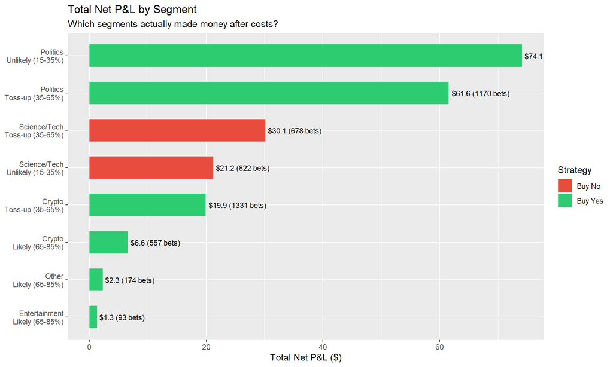

```r
bt_segment <- backtest_markets %>%
  mutate(segment = paste(category, price_zone, sep = "\n")) %>%
  group_by(segment, strategy) %>%
  summarise(
    n_bets   = n(),
    net_pnl  = sum(net_pnl),
    win_rate = mean(won),
    avg_pnl  = mean(net_pnl),
    .groups  = "drop"
  ) %>%
  arrange(desc(net_pnl))

ggplot(bt_segment, aes(x = reorder(segment, net_pnl), y = net_pnl)) +
  geom_col(aes(fill = strategy), width = 0.6) +
  geom_text(aes(label = paste0("$", round(net_pnl, 1), " (", n_bets, " bets)")),
            hjust = ifelse(bt_segment$net_pnl >= 0, -0.05, 1.05), size = 3) +
  scale_fill_manual(values = c("Buy Yes" = COL_POS, "Buy No" = COL_NEG)) +
  coord_flip() +
  labs(
    title    = "Total Net P&L by Segment",
    subtitle = "Which segments actually made money after costs?",
    x = NULL, y = "Total Net P&L ($)", fill = "Strategy"
  )
```

# 10 · Bot Implementation Notes

```r
# Gather key results for the summary
n_sig_ci      <- sum(ci_results$significant, na.rm = TRUE)
n_tradeable_f <- sum(exploitable_net$tradeable, na.rm = TRUE)

overall_bias <- snapshot_data %>%
  filter(snapshot_label == "1d") %>%
  summarise(bias = mean(yes_resolution) - mean(snap_price)) %>%
  pull(bias)

best_segment <- exploitable_net %>% filter(tradeable) %>% slice(1)

cat("## Entry Signals\n\n")
```

## Entry Signals

```r
cat("The bot should evaluate each new binary market against these criteria:\n\n")
```

The bot should evaluate each new binary market against these criteria:

```r
cat("1. **Category**: Match market tags to category rules\n")
```

1. **Category**: Match market tags to category rules

```r
cat("2. **Price zone**: Current Yes price maps to one of 5 zones\n")
```

2. **Price zone**: Current Yes price maps to one of 5 zones

```r
cat(sprintf("3. **Volume threshold**: Only trade markets with ≥ $%dK volume\n", MIN_VOLUME/1000))
```

3. **Volume threshold**: Only trade markets with ≥ $10K volume

```r
cat(sprintf("4. **Net edge threshold**: Only enter if estimated net edge > %.0f%%\n", MIN_EDGE_NET*100))
```

4. **Net edge threshold**: Only enter if estimated net edge > 1%

```r
cat("5. **Composite score**: Prefer segments with composite score > 0.5\n\n")
```

5. **Composite score**: Prefer segments with composite score > 0.5

```r
cat("## Position Sizing\n\n")
```

## Position Sizing

```r
cat("- Use **half-Kelly** fractions from §8.4\n")
```

- Use **half-Kelly** fractions from §8.4

```r
cat("- Cap any single position at 5% of bankroll\n")
```

- Cap any single position at 5% of bankroll

```r
cat("- Cap total exposure at 30% of bankroll (diversification)\n\n")
```

- Cap total exposure at 30% of bankroll (diversification)

```r
cat("## Risk Limits\n\n")
```

## Risk Limits

```r
cat("- **Daily loss limit**: Pause trading after 5% bankroll drawdown in a day\n")
```

- **Daily loss limit**: Pause trading after 5% bankroll drawdown in a day

```r
cat("- **Monthly review**: Recompute all bias tables monthly with fresh data\n")
```

- **Monthly review**: Recompute all bias tables monthly with fresh data

```r
cat("- **Edge decay**: If a segment's rolling 30-day bias flips sign, stop trading it\n")
```

- **Edge decay**: If a segment’s rolling 30-day bias flips sign, stop trading it

```r
cat("- **Minimum sample**: Don't trade a segment with < 30 historical resolved markets\n\n")
```

- **Minimum sample**: Don’t trade a segment with < 30 historical resolved markets

```r
cat("## Key Findings\n\n")
```

## Key Findings

```r
cat(sprintf("- **Overall market bias** (1d before close): %+.1f%%. %s.\n",
  overall_bias * 100,
  ifelse(abs(overall_bias) > 0.01,
    ifelse(overall_bias > 0, "Markets slightly underprice Yes", "Markets slightly overprice Yes"),
    "Markets are approximately well-calibrated overall")))
```

- **Overall market bias** (1d before close): +0.7%. Markets are approximately well-calibrated overall.

```r
cat(sprintf("- **Tradeable edges after costs**: %d segments survive (out of %d gross)\n",
  n_tradeable_f, nrow(exploitable)))
```

- **Tradeable edges after costs**: 8 segments survive (out of 10 gross)

```r
cat(sprintf("- **Statistically significant edges**: %d/%d top segments have bootstrap CIs excluding zero\n",
  n_sig_ci, nrow(ci_results)))
```

- **Statistically significant edges**: 8/10 top segments have bootstrap CIs excluding zero

```r
if (nrow(best_segment) > 0) {
  cat(sprintf("- **Best net edge**: %s × %s (%s, net edge %+.1f%%, n=%d)\n",
    best_segment$category, best_segment$price_zone, best_segment$strategy,
    best_segment$net_edge * 100, best_segment$n_markets))
}
```

- **Best net edge**: Politics × Unlikely (15-35%) (Buy Yes, net edge +10.1%, n=731)

```r
cat(sprintf("- **Backtest result**: $%.2f net P&L on %d $1 bets (%.2f¢ per bet avg)\n",
  total_net, total_bets, avg_net * 100))
```

- **Backtest result**: $217.14 net P&L on 5556 $1 bets (3.91¢ per bet avg)

```r
cat(sprintf("- **Max drawdown**: $%.2f · Sharpe per bet: %.3f\n", max_dd, sharpe_per_bet))
```

- **Max drawdown**: $-17.70 · Sharpe per bet: 0.086

```r
# Persistence insight
if (nrow(persistence) > 0) {
  best_persist <- persistence %>% slice(1)
  cat(sprintf("- **Most persistent edge**: %s — bias in correct direction %s of months\n",
    best_persist$segment, paste0(round(best_persist$persistence_pct, 0), "%")))
}
```

- **Most persistent edge**: Politics × Unlikely (15-35%) — bias in correct direction 100% of months

```r
cat("\n\n---\n\n")
```

```r
cat("> **Disclaimer**: Past calibration patterns do not guarantee future exploitability.")
```

> **Disclaimer**: Past calibration patterns do not guarantee future exploitability.

```r
cat(" Transaction costs, slippage, and market evolution may erode these edges.")
```

Transaction costs, slippage, and market evolution may erode these edges.

```r
cat(" Always paper-trade or use minimal size before scaling.")
```

Always paper-trade or use minimal size before scaling.

```r
cat(" The cost assumptions above (", SPREAD_COST*100, "% spread, ", WINNER_FEE*100,
    "% winner fee) are estimates — actual costs depend on market conditions and order size.\n")
```

The cost assumptions above ( 2 % spread, 2 % winner fee) are estimates — actual costs depend on market conditions and order size.

*Analysis generated on 2026-02-19 using 49753 closed binary markets and price history data.*

*v4 changes: fixed initial price bias (conditional analysis), added transaction cost model, temporal stability testing, liquidity filtering, Kelly sizing, composite scoring, simulated backtest. Removed: breakout analysis (null signal), DOW×category (multiple comparisons noise), monthly resolution rates, asymmetric error, price drift overview.*